# R Markdown: IS THERE A PLACENTAL MICROBIOTA? A CRITICAL REVIEW AND REANALYSIS OF PUBLISHED PLACENTAL MICROBIOTA DATASETS

Jonathan Panzer

November 23rd, 2022

# Contents

1. Preparation
   - Installing and loading packages
     - Loading packages
     - Samples included in the critical review and reanalysis
2. 16S rRNA hypervariable region V4 subset analysis
   - Dinsdale et al. setup
   - Olomu et al. setup
   - Seferovic et al. setup
   - Theis et al. setup
   - Theis_Winters et al. setup
   - Younge et al. setup
   - V4 Subset merging
   - V4 Normalization
   - V4 Subsetting
   - V4 PCoA plots (Figure 5)
   - V4 Heatmaps by Study (Figure 6)
3. Study-by-study analysis
   - DADA2 pipeline details
   - Study specific changes
   - de Goffau et al. analysis
     - de Goffau et al. data cleaning
     - de Goffau et al. Normalization
     - de Goffau et al. PTCWA PCoA
   - Dinsdale et al. analysis
     - Dinsdale et al. data cleaning
     - Dinsdale et al. subsets pre-DECONTAM
     - Dinsdale et al. DECONTAM
     - Dinsdale et al. normalization
     - Dinsdale et al. post-normalization subsets
     - Dinsdale et al. PCoAs
   - Gomez-Arango et al. analysis
     - Gomez-Arango et al. data cleaning
     - Gomez-Arango et al. normalization
     - Gomez-Arango et al. subsetting
   - Lauder et al. analysis
     - Lauder et al. data cleaning
     - Lauder et al. subsets pre-DECONTAM
     - Lauder et al. DECONTAM
     - Lauder et al. normalization
     - Lauder et al. post-normalization subsets
     - Lauder et al. PCoAs
   - Leiby et al. analysis
     - Leiby et al. data cleaning
     - Leiby et al. subsets pre-DECONTAM
     - Leiby et al. DECONTAM
     - Leiby et al. normalization
     - Leiby et al. post-normalization subsets
     - Leiby et al. PCoAs
   - Leon et al. analysis
     - Leon et al. data cleaning
     - Leon et al. DECONTAM
     - Leon et al. normalization
     - Leon et al. post-normalization subsets
     - Leon et al. PCoA
   - Liu et al. analysis
     - Liu et al. data cleaning
     - Liu et al. normalization
     - Liu et al. post-normalization subsets
     - Liu et al. agglomeration
     - Liu et al. PCoA
   - Olomu et al. analysis
     - Olomu et al. subset pre-DECONTAM
     - Olomu et al. DECONTAM
     - Olomu et al. normalization
     - Olomu et al. post-normalization subsets
     - Olomu et al. PCoAs
   - Parnell et al. analysis
     - Parnell et al. data cleaning
     - Parnell et al. subset pre-DECONTAM
     - Parnell et al. DECONTAM
     - Parnell et al. normalization
     - Parnell et al. post-normalization subsets
     - Parnell et al. PCoA
   - Seferovic et al. analysis
     - Seferovic et al. normalization
     - Seferovic et al. post-normalization subset
     - Seferovic et al. PCoA
   - Sterpu et al. analysis
     - Sterpu et al. data cleaning
     - Sterpu et al. DECONTAM
     - Sterpu et al. normalization
     - Sterpu et al. post-normalization subsets
     - Sterpu et al. PCoA
   - Tang et al. analysis
     - Tang et al. data cleaning
     - Tang et al. normalization
     - Tang et al. post-normalization subset
   - Theis et al. analysis
     - Theis et al. additional data cleaning
     - Theis et al. DECONTAM
     - Theis et al. normalization
     - Theis et al. post-normalization subsets
     - Theis et al. PCoAs
   - Theis_Winters et al. analysis
     - Theis_Winters et al. data cleaning
     - Theis_Winters et al. DECONTAM
     - Theis_Winters et al. normalization
     - Theis_Winters et al. post-normalization subsets
     - Theis_Winters et al. PCoA
   - Younge et al. analysis
     - Younge et al. additional data cleaning
     - Younge et al. normalization
     - Younge et al. post-normalization subset
     - Younge et al. PCoA
4. Statistics
   - Table S2 Statistics

# Preparation

First download the respository `Placental_Microbiota_Reanalysis` by navigating to [the github repository](https://github.com/jp589/Placental_Microbiota_Reanalysis) and clicking on `Code`>`Download Zip`. Proceed to unzip it by right-clicking to extract the files. Then place the `Placental_Microbiota_Reanalysis` directory wherever is convenient. After starting RStudio with R (Version 3.6.1) loaded, under `File` select `New Project` -> `Existing Directory` and change to project working directory to the `Placental_Microbiota_Reanalysis` directory. Creating a new project may cause this Rmarkdown file to close if the `.Rmd` version is open in the current session, but just reopen it after the new project is created. When running the code for this critical review and reanalysis, is is preferable to use the `.Rmd` version instead of copy-pasting from the `.html` version. In addition, it is preferable to run the code as chunks by clicking the green arrow button located in the top-right corner of each chunk, or knitting the entire document to HTML once all of the package installations have been taken care of.

This `.Rmd` document was successfully run with RStudio (Version 1.4.1103) and R (Version 3.6.1). The version of RStudio can be checked under `Help` -> `About RStudio`. The version of R can be checked and changed under `Tools` -> `Global Options`. In the `General` side tab, there should be an R version listed near the top of the window, which can be changed, but this requires RStudio to restart before the version change takes effect. RStudio version 1.4.1717 is stable and can be downloaded [here](https://dailies.rstudio.com/version/1.4.1717-3/). R version 3.6.1 can be downloaded [here](https://cran.r-project.org/bin/windows/base/old/3.6.1/).

In addition to downloading `RStudio` and `R`, `Rtools` is also necessary. It is required for the installation of the R package `devtools`, which is used here to install older versions of packages and packages residing on github. `Rtools` version 35, which is compatible with `R/3.6.1`, can be downloaded [here](https://cran.r-project.org/bin/windows/Rtools/history.html). Be sure to leave the installation directory as the default `C:/Rtools/`.

`BLAST+` from the NCBI is required to run local BLAST searches to the 16S rRNA gene sequence database located in the `dada2tools` R package. The `BLAST+` installation instructions are [here](https://www.ncbi.nlm.nih.gov/books/NBK569861/) and the latest versions for download can be found [here](https://ftp.ncbi.nlm.nih.gov/blast/executables/LATEST/). Once the appropriate and compatible version of `BLAST+` is downloaded, it must be installed. To check if `BLAST+` was successfully installed, open a terminal or command prompt and type `blastn`. If a `BLAST query/options error...` is returned, the installation was successful.

**When asked to update packages, or install from source, press enter to skip updates or select option “no”.**

If the `install.packages("package.name", force = TRUE)` commands are not successful, try installing with the command `BiocManager::install("package.name")`.

This first chunk details the current system environment. and installs the R packages `BiocManager`, `devtools`, and `usethis`. It also puts `Rtools` on the PATH system environment variable so that it can be accessed by `R`.

```r
if (!requireNamespace("BiocManager", quietly = TRUE)){
  install.packages("BiocManager")
}

#Final check to ensure that the file path is properly set. `getwd()` should return the file path with "/Placental_Microbiota_Reanalysis" at the end. Therefore, `grepl()` should return TRUE.
grepl(pattern = "(.*)(Placental_Microbiota_Reanalysis)$", x = getwd())
```

```
## [1] FALSE
```

```r
#allow R to find Rtools via environment variable
Sys.setenv(PATH=paste("C:/Rtools/bin",Sys.getenv("PATH"),sep=";"))
Sys.setenv(BINPREF="C:/Rtools/mingw_$(WIN)/bin/")
#double checking that the path is correct
Sys.which("make")
```

```
##                        make
## "C:\\Rtools\\bin\\make.exe"
```

```r
#devtools required to install package `dada2tools`
if (!requireNamespace("devtools", quietly = TRUE)){
  BiocManager::install("devtools")
}
#installs version 2.0.0 of the usethis package if not currently installed
if(!packageVersion("usethis") == "2.0.0"){
  devtools::install_version("usethis", version = "2.0.0")
}

#installs version 2.3.1 of the devtools package if not currently installed
if(!packageVersion("devtools") == "2.3.1"){
  devtools::install_version("devtools", version = "2.3.1")
}

library(devtools)
```

### Installing packages

This Rmarkdown file details how the data were analyzed and how the figures/tables were generated. All analysis was performed in R using the packages listed in the following chunk and their dependencies. This chunk is not evaluated when the entire document is knit, but these packages need to be installed before the document will successfully knit. Packages can be installed with several commands. The following chunk lists the code for the specific packages, which were used to successfully knit the document. If a package has never been installed before, it may be necessary to first install the package with `BiocManager::install("package_name")`, and then use `devtools::install_version("package_name", version = "1.2.3")` for the exact version. If a package has been installed but was built under a different R 3.6 version, it may be necessary to re-install packages using `install.packages("package_name", force = TRUE)`, or to select a specific version with `devtools::install_version("package_name", version = "1.2.3")`. `install.packages("Package_Name")` is also another option.

For exact versions please **skip updates to other packages when asked**.

```r
#The following packages need to be installed as R/3.6.1 compatible versions

#installs Rcpp
devtools::install_version("Rcpp", version = "1.0.5")
#installs dada2
devtools::install_url("https://bioconductor.org/packages/3.10/bioc/src/contrib/Archive/dada2/dada2_1.14.0.tar.gz")
#installs dplyr
devtools::install_version("dplyr", version = "1.0.3")
#installs decontam version 1.6.0
devtools::install_version("decontam", version = "1.6.0")
#installs phyloseq
devtools::install_version("phyloseq", version = "1.30.0")
#installs stringr
devtools::install_version("stringr", version = "1.3.1")
#installs readxl
devtools::install_version("readxl", version = "1.3.0")
#installs openxlsx
devtools::install_version("openxlsx", version = "4.2.2")
#vegan package version 2.5.6 is compatible with R/3.6.1. vegan/2.5.6 requires permute/0.9.4. Install with:
devtools::install_version("permute", "0.9.4"); devtools::install_version("vegan", "2.5.6")
#installs ecodist version earlier than 2.0.7
devtools::install_version("ecodist", version = "2.0.5")
#installs RPushbullet version earlier than 0.3.3
devtools::install_version("RPushbullet", version = "0.3.2")
#installs magrittr version 2.0.1
install.packages("magrittr")
#installs pdftools version earlier than 2.3.1
devtools::install_version("pdftools", version = "2.2")
#installs ComplexHeatmap
devtools::install_version("ComplexHeatmap", version = "2.2.0")
#installs ggplot2 version earlier than 3.3.3
devtools::install_version("ggplot2", version = "3.3.2")
#installs purrr version 0.3.4
install.packages("purrr")
#installs knitr version earlier than 1.31
devtools::install_version("knitr", version = "1.30")
#installs circlize version earlier than 0.4.12
devtools::install_version("circlize", version = "0.4.10")
#installs seqinr version earlier than 4.2.5
devtools::install_version("seqinr", version = "4.2.4")
#installs pairwiseAdonis version 0.4
devtools::install_github("pmartinezarbizu/pairwiseAdonis/pairwiseAdonis")
#installs gifski version 0.8.3
devtools::install_version("gifski", version = "0.8.3")
#installs pdftools version 2.2
devtools::install_version("pdftools", version = "2.2")
```

### Loading packages

The following chunk essentially loads all the functions contained within each package so that the functions can be called without prefacing the package names each time.

```r
library(dada2)
library(decontam)
library(dplyr)
library(phyloseq)
library(stringr)
library(readxl)
library(openxlsx)
library(vegan)
library(ecodist)
library(RPushbullet)
library(magrittr)
```

```r
library(pdftools)
library(ComplexHeatmap)
library(ggplot2)
library(purrr)
library(knitr)
library(circlize)
library(seqinr)
library(pairwiseAdonis)
#also need to install dada2tools from github.
if (!requireNamespace("dada2tools", quietly = TRUE)){
  devtools::install_github("jp589/dada2tools", build_vignettes = TRUE)
}
library(dada2tools)

#stores original palette
pal <- palette()
#package versions used
```

### Samples included in the critical review and reanalysis

Some samples did not meet the quality criteria of this critical review and reanalysis and were therefore removed before DADA2 processing. Here is a list of all samples that passed the quality filtering step.

```r
#loads all merged sample data
de_Goffau_merged <- read.csv("deGoffau_merged.csv", stringsAsFactors = FALSE)
Lauder_merged <- read.csv("Lauder_merged.csv", stringsAsFactors = FALSE)
Leiby_merged <- read.csv("Leiby_merged.csv", stringsAsFactors = FALSE)
Olomu_merged <- read.csv("Olomu_merged.csv", stringsAsFactors = FALSE)
Parnell_merged <- read.csv("Parnell_merged.csv", stringsAsFactors = FALSE)
Theis_merged <- read.csv("Theis_merged.csv", stringsAsFactors = FALSE)
Theis_Winters_merged <- read.csv("Theis_Winters_merged.csv", stringsAsFactors = FALSE)
Sterpu_merged <- read.csv("Sterpu_merged.csv", stringsAsFactors = FALSE)
Dinsdale_merged <- read.csv("Dinsdale_merged.csv", stringsAsFactors = FALSE)
Tang_merged <- read.csv("Tang_merged.csv", stringsAsFactors = FALSE)
Liu_merged <- read.csv("Liu_merged.csv", stringsAsFactors = FALSE)
GA_merged <- read.csv("GomezArango_merged.csv", stringsAsFactors = FALSE)
Younge_merged <- read.csv("Younge_merged.csv", stringsAsFactors = FALSE)
Leon_merged <- read.csv("Leon_merged.csv", stringsAsFactors = FALSE)
Seferovic_merged <- read.csv("Seferovic_merged.csv", stringsAsFactors = FALSE)

#creates list of samples which passed quality filtering and were used in the reanalysis
High_Quality_Samples <- list(
    de_Goffau = colnames(de_Goffau_merged)[9:ncol(de_Goffau_merged)],
    Lauder = colnames(Lauder_merged)[9:ncol(Lauder_merged)],
    Leiby = colnames(Leiby_merged)[9:ncol(Leiby_merged)],
    Olomu = colnames(Olomu_merged)[9:ncol(Olomu_merged)],
    Parnell = colnames(Parnell_merged)[9:ncol(Parnell_merged)],
    Theis = colnames(Theis_merged)[9:ncol(Theis_merged)],
    Theis_Winters = colnames(Theis_Winters_merged)[9:ncol(Theis_Winters_merged)],
    Sterpu = colnames(Sterpu_merged)[9:ncol(Sterpu_merged)],
    Dinsdale = colnames(Dinsdale_merged)[9:ncol(Dinsdale_merged)],
    Tang = colnames(Tang_merged)[9:ncol(Tang_merged)],
    Liu = colnames(Liu_merged)[9:ncol(Liu_merged)],
    Gomez_Arango = colnames(GA_merged)[9:ncol(GA_merged)],
    Younge = colnames(Younge_merged)[9:ncol(Younge_merged)],
    Leon = colnames(Leon_merged)[9:ncol(Leon_merged)],
    Seferovic = colnames(Seferovic_merged)[9:ncol(Seferovic_merged)])
```

# 16S rRNA hypervariable region V4 subset analysis

This begins the portion of code used to generate figures 5 and 6. For each of the six studies, the DADA2 analyzed sequence data, which is stored in a `Study_Name_merged.csv` file, was cleaned (e.g., mitochondrial, chloroplast, and reads unclassified at the phylum level or above were removed from the dataset). In addition, samples with less than 100 reads after the prior read removal were removed. For the exact cleaning process, the code for the function `dadaset_clean()` can be viewed by typing the function `dada2tools::dadaset_clean` without parentheses and pressing enter. In addition, publicly available metadata was stored for each study, usually titled `Study_Name_SraRunTable.csv`. ASVs not classified at the genus level in tables and figures were compared to bacterial type strains in the NCBI BLAST sequence database. Sequences were reclassified to the genus level with the highest percent identity greater than 95%.

### Dinsdale et al. setup

This chunk processes the Dinsdale et al. dataset after DADA2 processing. into an ASV count table with corresponding taxonomy and metadata.

```r
#Preparing Dinsdale et al. for inclusion in the V4 subset
#Loads both sequence and metadata
Dinsdale_merged <- read.csv(file = "Dinsdale_merged.csv", stringsAsFactors = FALSE)
Dinsdale_meta <- read.csv(file = "Dinsdale_SraRunTable.csv", stringsAsFactors = FALSE)

#Subsets metadata columns to those pertinent to this analysis and renames them
Dinsdale_meta_select <- Dinsdale_meta %>% select_if(colnames(.) %in% c("Run", "Sample_name", "title")); colnames(Dinsdale_meta_select) <- c("Run", "Sample", "Type")

#cleans sequence data and renames rows with numbered ASVs
Dinsdale_merged_clean <- dadaset_clean(Dinsdale_merged, read_thresh = 100)
```

```
## Originally there were 2376 taxa.
##  831 were not bacterial or classified at phylum level.
##  0 were mitochondrial. 11 were chloroplast.
##  1534 taxa remain. 0 samples eliminated with less than 100 reads:
```

```r
rownames(Dinsdale_merged_clean) <- paste0("ASV", 1:nrow(Dinsdale_merged_clean))

#splits merged sequence data into an `ASV` count table and a taxonomy `TAX` object. In order to merge the studies later on, the `TAX` object needs to have an ASV column with numbered ASVs.
Dinsdale_ASV <- Dinsdale_merged_clean[,9:159]
Dinsdale_TAX <- data.frame(
  ASV = rownames(Dinsdale_merged_clean),
  Dinsdale_merged_clean[,1:8],
  row.names = rownames(Dinsdale_merged_clean),
  stringsAsFactors = FALSE)

#filters metadata to samples which passed the 100 read cutoff
Dinsdale_META <- Dinsdale_meta_select %>% filter(Dinsdale_meta_select$Run %in% colnames(Dinsdale_ASV))

#recodes gestational age and delivery metadata for placental samples, and technical controls.
for (i in 1:length(Dinsdale_META$Type)){
    if (Dinsdale_META$Type[i] == "Placenta"){
        Dinsdale_META$GA[i] <- "Unknown"
        Dinsdale_META$Delivery[i] <- "Unknown"
    } else {
        Dinsdale_META$GA[i] <- NA
        Dinsdale_META$Delivery[i] <- NA
    }
}
Dinsdale_META$Type <- Dinsdale_META$Type %>% recode(., "NEG" = "Technical Control", "Vagina" = "Vaginal Swab")
#Adds a `Reads` (total reads per sample), `Study` column, and gives metadata rows sample names.
Dinsdale_META$Reads <- unlist(colSums(Dinsdale_ASV));Dinsdale_META$Study <- "Dinsdale"
rownames(Dinsdale_META) <- Dinsdale_META$Sample

#Reclassifying ASV10 since its sequence shares 96.44% similarity to type strains in the genus Phenylobacterium
Dinsdale_TAX$Genus[10] <- "Phenylobacterium*"
```

### Olomu et al. setup

The following chunk processes the Olomu et al. dataset similarly to the previous chunk.

```r
#Preparing Olomu et al. for inclusion in the V4 Subset
#Loads both sequence and metadata
Olomu_merged <- read.csv("Olomu_merged.csv", stringsAsFactors = FALSE)
Olomu_meta <- read.csv(file = "Olomu_SraRunTable.csv", stringsAsFactors = FALSE)

#Subsets metadata columns to those pertinent to this analysis and renames them
Olomu_meta_select <- Olomu_meta %>% select_if(colnames(.) %in% c("Run", "isolation_source", "Library.Name"))
Olomu_meta_select <- Olomu_meta_select %>% filter(Run %in% colnames(Olomu_merged[,9:ncol(Olomu_merged)])); colnames(Olomu_meta_select)[2:3] <- c("Type", "Sample")
#removes extraneous sample name text found in all sample names
Olomu_meta_select$Sample <- gsub(pattern = "(\\S*)(_GDM_Placental_microbiome)", x = Olomu_meta_select$Sample, replacement = "\\1")
#removes cord blood and maternal blood samples from metadata
Olomu_meta_select <- Olomu_meta_select[!str_detect(string = Olomu_meta_select$Type, pattern = "blood$"),]
#filters ASV count table to match metadata
Olomu_merged <- cbind(Olomu_merged[,1:8], Olomu_merged %>% select_if(colnames(.) %in% Olomu_meta_select$Run))
#cleans sequence data and renames rows with numbered ASVs
Olomu_merged_clean <- dadaset_clean(Olomu_merged, read_thresh = 100); rownames(Olomu_merged_clean) <- paste0("ASV", 1:nrow(Olomu_merged_clean))
```

```
## Originally there were 10095 taxa.
##  8840 were not bacterial or classified at phylum level.
##  0 were mitochondrial. 2 were chloroplast.
##  1253 taxa remain. 248 samples eliminated with less than 100 reads: SRR10298912 SRR10298918 SRR10298923 SRR10298934 SRR10298940 SRR10298951 SRR10298952 SRR10298953 SRR10298954 SRR10298956 SRR10298959 SRR10298960 SRR10298962 SRR10298965 SRR10298966 SRR10298970 SRR10298971 SRR10298976 SRR10298977 S…
```

```r
#splits merged sequence data into an `ASV` count table and a taxonomy `TAX` object. In order to merge the studies later on, the `TAX` object needs to have an ASV column with numbered ASVs.
Olomu_ASV <- Olomu_merged_clean[,-c(1:8)]
Olomu_TAX <- data.frame(ASV = rownames(Olomu_merged_clean), Olomu_merged_clean[,1:8], row.names = rownames(Olomu_merged_clean), stringsAsFactors = FALSE)

#filters metadata to samples which passed the 100 read cutoff
Olomu_META <- Olomu_meta_select %>% filter(Run %in% colnames(Olomu_ASV))

#recodes names for sample types, gestational age and delivery metadata for placental samples, and technical controls.
Olomu_META$Type <- case_when(
  str_detect(string = Olomu_META$Sample, pattern = "^EC") ~ "Pos_Control",
  TRUE ~ Olomu_META$Type
)
Olomu_META$Type <- Olomu_META$Type %>% recode(., "not applicable" = "Technical Control", "vagina-rectal swabs" = "VR_Swab", "placental sample" = "Placenta")
for (i in 1:length(Olomu_META$Type)){
    if (Olomu_META$Type[i] == "Placenta"){
        Olomu_META$GA[i] <- "Term"
        Olomu_META$Delivery[i] <- "Cesarean"
    } else {
        Olomu_META$GA[i] <- NA
        Olomu_META$Delivery[i] <- NA
    }
}
#Adds a `Reads` (total reads per sample), `Study` column, and gives metadata rows sample names. Finally reorders metadata to match for future combination.
Olomu_META$Reads <- unlist(colSums(Olomu_ASV)); Olomu_META$Study <- "Olomu"; rownames(Olomu_META) <- Olomu_META$Sample; Olomu_META <- Olomu_META[,c(1,3,2,4:7)]

#Reclassifying ASV484 since its sequence shares 95.65% identity to type strain Desulfuromonas soudanensis
Olomu_TAX$Genus[484] <- "Desulfuromonas*"
```

### Seferovic et al. setup

The following chunk processes the Seferovic et al. dataset similarly to the previous chunk.

```r
#preparing Seferovic et al. for inclusion in the V4 Subset
#Loads both sequence and metadata
Seferovic_merged <- read.csv("Seferovic_merged.csv", stringsAsFactors = FALSE)
Seferovic_meta <- read.csv(file = "Seferovic_SraRunTable.csv", stringsAsFactors = FALSE)

#Subsets metadata columns to those pertinent to this analysis and renames them
Seferovic_meta_select <- Seferovic_meta %>% select_if(colnames(.) %in% c("Run", "Library.Name"))
colnames(Seferovic_meta_select)[2] <- "Sample"
#removes extraneous sample name text found in all sample names
Seferovic_meta_select$Sample <- gsub(pattern = "(Aagaard.)(.*)(_AagaardK)", x = Seferovic_meta_select$Sample, replacement = "\\2")

#cleans sequence data and renames rows with numbered ASVs
Seferovic_merged_clean <- dadaset_clean(df = Seferovic_merged, read_thresh = 100); rownames(Seferovic_merged_clean) <- paste0("ASV", 1:nrow(Seferovic_merged_clean))
```

```
## Originally there were 4663 taxa.
##  3352 were not bacterial or classified at phylum level.
##  11 were mitochondrial. 19 were chloroplast.
##  1281 taxa remain. 0 samples eliminated with less than 100 reads:
```

```r
#splits merged sequence data into an `ASV` count table and a taxonomy `TAX` object. In order to merge the studies later on, the `TAX` object needs to have an ASV column with numbered ASVs.
Seferovic_ASV <- Seferovic_merged_clean[,8:ncol(Seferovic_merged_clean)]
Seferovic_TAX <- data.frame(ASV = rownames(Seferovic_merged_clean), Seferovic_merged_clean[,1:7], Species = as.character(NA), row.names = rownames(Seferovic_merged_clean), stringsAsFactors = FALSE)

#filters metadata to samples which passed the 100 read cutoff
Seferovic_META <- Seferovic_meta_select %>% filter(Run %in% colnames(Seferovic_ASV))

#recodes names for sample types, gestational age and delivery metadata for placental samples, and technical controls.
for (i in 1:length(Seferovic_META$Sample)){
    if (Seferovic_META$Sample[i] == "Blank1" | Seferovic_META$Sample[i] == "Blank2"){
        Seferovic_META$Type[i] <- "Technical Control"
        Seferovic_META$GA[i] <- NA
        Seferovic_META$Delivery[i] <- NA
    } else {
        Seferovic_META$Type[i] <- "Placenta"
        Seferovic_META$GA[i] <- "Unknown"
        Seferovic_META$Delivery[i] <- "Unknown"
    }
}

#Adds a `Reads` (total reads per sample), `Study` column, and gives metadata rows sample names.
Seferovic_META$Reads <- unlist(colSums(Seferovic_ASV)); Seferovic_META$Study <- "Seferovic"; rownames(Seferovic_META) <- Seferovic_META$Sample

#ASV3 was not reclassified since it only shares 93.31% identity to Ruminococcus type strains
```

### Theis et al. setup

The following chunk processes the Theis et al. dataset similarly to the previous chunk.

```r
#preparing Theis et al. for inclusion in the V4 Subset
#Loads both sequence and metadata
Theis_merged <- read.csv(file = "Theis_merged.csv", stringsAsFactors = FALSE)
Theis_meta <- read.csv(file = "Theis_SraRunTable.csv", stringsAsFactors = FALSE)

#Subsets metadata columns to those pertinent to this analysis and renames them
Theis_meta_select <- Theis_meta %>% select_if(colnames(.) %in% c("Run", "Library.Name"))
colnames(Theis_meta_select)[2] <- "Sample"

#Subsets to regular PCR amplified samples
Theis_meta_select <- Theis_meta_select[1:101,]
Theis_merged <- cbind(Theis_merged[,1:8], Theis_merged %>% select_if(colnames(.) %in% Theis_meta_select$Run))

#cleans sequence data and renames rows with numbered ASVs
Theis_merged_clean <- dadaset_clean(Theis_merged, read_thresh = 100); rownames(Theis_merged_clean) <- paste0("ASV", 1:nrow(Theis_merged_clean))
```

```
## Originally there were 1925 taxa.
##  954 were not bacterial or classified at phylum level.
##  0 were mitochondrial. 4 were chloroplast.
##  967 taxa remain. 0 samples eliminated with less than 100 reads:
```

```r
#splits merged sequence data into an `ASV` count table and a taxonomy `TAX` object. In order to merge the studies later on, the `TAX` object needs to have an ASV column with numbered ASVs.
Theis_ASV <- Theis_merged_clean[,9:ncol(Theis_merged_clean)]
Theis_TAX <- data.frame(ASV = rownames(Theis_merged_clean), Theis_merged_clean[,1:8], row.names = rownames(Theis_merged_clean), stringsAsFactors = FALSE)

#filters metadata to samples which passed the 100 read cutoff
Theis_META <- Theis_meta_select %>% filter(Run %in% colnames(Theis_ASV))

#recodes names for sample types, gestational age and delivery metadata for placental samples, and technical controls.
for (i in 1:length(Theis_META$Run)){
    if (str_detect(string = Theis_META$Sample[i], pattern = "AC")|str_detect(string = Theis_META$Sample[i], pattern = "V")){
        Theis_META$Type[i] <- "Placenta"
        Theis_META$GA[i] <- "Term"
        Theis_META$Delivery[i] <- "Cesarean"
    } else {
        Theis_META$Type[i] <- "Technical Control"
        Theis_META$GA[i] <- NA
        Theis_META$Delivery[i] <- NA
    }
}

#Adds a `Reads` (total reads per sample), `Study` column, and gives metadata rows sample names.
Theis_META$Reads <- unlist(colSums(Theis_ASV)); Theis_META$Study <- "Theis"; rownames(Theis_META) <- Theis_META$Sample
```

### Theis, Winters et al. setup

The following chunk processes the Winters et al. dataset similarly to the previous chunk.

```r
#preparing Winters et al. for inclusion in the V4 Subset
#Loads both sequence and metadata. `Key` correlates run numbers with sample names
Theis_Winters_merged <- read.csv("Theis_Winters_merged.csv", stringsAsFactors = FALSE)
Theis_Winters_meta <- read.csv("Theis_Winters_meta.csv", header = TRUE, stringsAsFactors = FALSE)
key <- read.xlsx("Theis_Winters_SRRkey_metadata.xlsx")

#Adds an `S` to entries in `Winters_meta` Sample column which start with a digit
for(i in 1:nrow(Theis_Winters_meta)){
    if(str_detect(string = Theis_Winters_meta$Sample[i], pattern = "\\b\\d+") == TRUE){
        Theis_Winters_meta$Sample[i] <- paste0("S", Theis_Winters_meta$Sample[i])
    }
}

#merges key with metadata by sample names, then reorders metadata
Theis_Winters_meta <- merge(Theis_Winters_meta, key[,1:2], by = "Sample")
Theis_Winters_meta <- Theis_Winters_meta[,c(10,1:9)]

#subsets to high quality samples
Theis_Winters_merged <- cbind(Theis_Winters_merged[,1:8], Theis_Winters_merged %>% select_if(colnames(.) %in% Theis_Winters_meta$Sample))

#cleans sequence data and renames rows with numbered ASVs
Theis_Winters_merged_clean <- dadaset_clean(Theis_Winters_merged, read_thresh = 100); rownames(Theis_Winters_merged_clean) <- paste0("ASV", 1:nrow(Theis_Winters_merged_clean))
```

```
## Originally there were 3134 taxa.
##  117 were not bacterial or classified at phylum level.
##  0 were mitochondrial. 16 were chloroplast.
##  3001 taxa remain. 55 samples eliminated with less than 100 reads: S18 S37 S38 S57 S64 S96 S111 S114 S155 S190 S191 S199 S209 S224 S229 S230 S232 S260 S269 S270 S277 S283 S284 S290 S298 S301 S312 S316 S341 S345 S385 S390 S391 S395 S398 S400 S407 S413 S488 S513 S521 S523 S550 S567 S589 S597 S634 S…
```

```r
#subsets to samples left after cleaning data and reorders metadata according to column names in merged data
Theis_Winters_META <- Theis_Winters_meta %>% filter(Sample %in% colnames(Theis_Winters_merged_clean)[9:ncol(Theis_Winters_merged_clean)])
Theis_Winters_META <- Theis_Winters_META[match(x = colnames(Theis_Winters_merged_clean)[9:ncol(Theis_Winters_merged_clean)], table = Theis_Winters_META$Sample),]
#Blank samples do not have gestational age or delivery data
Theis_Winters_META[450:461,7:8] <- NA

#renames columns as sample run number
colnames(Theis_Winters_merged_clean)[9:ncol(Theis_Winters_merged_clean)] <- Theis_Winters_META$Run

#splits merged sequence data into an `ASV` count table and a taxonomy `TAX` object. In order to merge the studies later on, the `TAX` object needs to have an ASV column with numbered ASVs.
Theis_Winters_ASV <- Theis_Winters_merged_clean[,9:ncol(Theis_Winters_merged_clean)]
Theis_Winters_TAX <- data.frame(ASV = rownames(Theis_Winters_merged_clean), Theis_Winters_merged_clean[,1:8], row.names = rownames(Theis_Winters_merged_clean), stringsAsFactors = FALSE)

#recodes names for sample types, gestational age and delivery metadata for placental samples, and technical controls.
Theis_Winters_META$Type <- c(rep("Placenta", (nrow(Theis_Winters_META)-12)), rep("Technical Control", 12))
Theis_Winters_META$Delivery <- Theis_Winters_META$Delivery %>% recode(., "CS" = "Cesarean")

#Adds a `Reads` (total reads per sample), `Study` column, and gives metadata rows sample names. Finally reorders metadata to match for future combination.
Theis_Winters_META$Reads <- unlist(colSums(Theis_Winters_ASV)); Theis_Winters_META$Study <- "Theis_Winters"; rownames(Theis_Winters_META) <- Theis_Winters_META$Sample; Theis_Winters_META <- Theis_Winters_META[,c(1,2,11,7:8,12:13)]
```

### Younge et al. setup

The following chunk processes the Younge et al. dataset similarly to the previous chunk.

```r
#preparing Younge et al. for inclusion in the V4 Subset
#Loads both sequence and metadata
Younge_merged <- read.csv(file = "Younge_merged.csv", stringsAsFactors = FALSE)
Younge_meta <- read.csv(file = "Younge_SraRunTable.csv", stringsAsFactors = FALSE)

#Subsets metadata columns to those pertinent to this analysis and renames them
Younge_meta_select <- Younge_meta %>% select_if(colnames(.) %in% c("Run", "Site", "Subject"))
colnames(Younge_meta_select)[2] <- "Type"

#cleans sequence data and renames rows with numbered ASVs
Younge_merged_clean <- dadaset_clean(Younge_merged, read_thresh = 100); rownames(Younge_merged_clean) <- paste0("ASV", 1:nrow(Younge_merged_clean))
```

```
## Originally there were 1640 taxa.
##  163 were not bacterial or classified at phylum level.
##  1 were mitochondrial. 1 were chloroplast.
##  1475 taxa remain. 0 samples eliminated with less than 100 reads:
```

```r
#splits merged sequence data into an `ASV` count table and a taxonomy `TAX` object. In order to merge the studies later on, the `TAX` object needs to have an ASV column with numbered ASVs.
Younge_ASV <- Younge_merged_clean[,9:ncol(Younge_merged_clean)]
Younge_TAX <- data.frame(ASV = rownames(Younge_merged_clean), Younge_merged_clean[,1:8], row.names = rownames(Younge_merged_clean), stringsAsFactors = FALSE)

#filters metadata to samples which passed the 100 read cutoff
Younge_META <- Younge_meta_select %>% filter(Run %in% colnames(Younge_ASV))

#recodes names for sample types, gestational age and delivery metadata for placental samples, and technical controls.
Younge_META$Type <- Younge_META$Type %>% recode("placenta" = "Placenta", "maternal_vagina" = "Vagina")
Younge_META <- Younge_META %>% mutate(Sample = paste(Type, Subject, sep = "-"))
for (i in 1:length(Younge_META$Type)){
    if (Younge_META$Type[i] == "Placenta"){
        Younge_META$GA[i] <- "Unknown"
        Younge_META$Delivery[i] <- "Cesarean"
    } else {
        Younge_META$Type[i] <- "Vagina"
        Younge_META$GA[i] <- NA
        Younge_META$Delivery[i] <- NA
    }
}

#Adds a `Reads` (total reads per sample), `Study` column, and gives metadata rows sample names. Finally reorders metadata to match for future combination.
Younge_META$Reads <- unlist(colSums(Younge_ASV)); Younge_META$Study <- "Younge"; rownames(Younge_META) <- Younge_META$Sample; Younge_META <- Younge_META[,c(1,4,2,5:8)]
```

## V4 Subset merging

Now that all six studies are loaded into the R environment, we can merge the datasets by exact sequence.

```r
#combines all six studies
V4_Combo_S6 <- combine_V4(ASV_datasets = list(Dinsdale_ASV, Olomu_ASV, Seferovic_ASV, Theis_ASV, Theis_Winters_ASV, Younge_ASV), TAX_datasets = list(Dinsdale_TAX,  Olomu_TAX, Seferovic_TAX, Theis_TAX, Theis_Winters_TAX, Younge_TAX), META_datasets = list(Dinsdale_META, Olomu_META, Seferovic_META, Theis_META, Theis_Winters_META,Younge_META))

#splits object into ASV, TAX, and META parts
V4_S6_ASV <- V4_Combo_S6$ASV; V4_S6_TAX <- V4_Combo_S6$TAX; V4_S6_META <- V4_Combo_S6$META

#gives row names ASV numbers
rownames(V4_S6_TAX) <- V4_S6_TAX$ASV

#adds column which combines delivery and gestational age metadata and recodes it
V4_S6_META <- V4_S6_META %>% mutate(Del_GA = paste(Delivery, GA))
V4_S6_META$Del_GA <- V4_S6_META$Del_GA %>% recode(., "NA NA" = "Technical Control", "Unknown Unknown" = "Unknown")
V4_S6_META$Del_GA <- case_when(
  V4_S6_META$Type == "Vagina" ~ "NA",
  V4_S6_META$Type == "Placenta" ~ V4_S6_META$Del_GA,
  V4_S6_META$Type == "Technical Control" ~ V4_S6_META$Del_GA
)

#NCBI BLAST search reveals 100% match to Serratia marsescens type strain
V4_S6_TAX$Genus[match(x = "ASV2555", table = V4_S6_TAX$ASV)] <- "Serratia*"
```

## V4 Normalization

Now we can normalize the dataset so that sampling depth is even across all samples.

```r
#converts dataframes to phyloseq object
phy <- phyloseqize(merged_df = V4_S6_ASV, taxa_as_rows = TRUE, keep_ASV_nums = TRUE, tax_df = V4_S6_TAX)

#normalizes samples to the greater of either the minimum number of sequences per sample in a dataset or 100. Samples with less than 100 sequences at this point are removed.
rarefied <- rarefy_even_depth(phy, sample.size = max(min(sample_sums(phy)), 100), rngseed = 1, replace = FALSE)
```

```
## `set.seed(1)` was used to initialize repeatable random subsampling.
```

```
## Please record this for your records so others can reproduce.
```

```
## Try `set.seed(1); .Random.seed` for the full vector
```

```
## ...
```

```
## 4209OTUs were removed because they are no longer
## present in any sample after random subsampling
```

```
## ...
```

```r
#returns phyloseq object to merged dataframe
merged_rare <- dephy(rarefied)

#splits dataframe into `ASV` count table, `TAX` taxonomy, and ensures that metadata is current with remaining samples.
V4_rare_ASV <- merged_rare[,10:ncol(merged_rare)]; V4_rare_TAX <- merged_rare[,1:9]; V4_rare_META <- V4_S6_META %>% filter(Run %in% colnames(V4_rare_ASV))
```

## V4 Subsetting

This sub-analysis will only be evaluating placental samples and technical controls so we can subset the combined dataset to these sample types.

```r
#subsets metadata to only placental samples and technical controls.
V4_META_PTC <- V4_rare_META %>% filter(Type == "Placenta" | Type == "Technical Control")
#subsets ASV count table to samples remaining in metadata and removes ASVs which no longer have reads remaining in the dataset
V4_ASV_PTC <- V4_rare_ASV %>% select_if(colnames(.) %in% V4_META_PTC$Run); V4_ASV_PTC <- V4_ASV_PTC %>% filter(rowSums(.) > 0)
#filters taxonomy to match remaining ASVs in ASV count table
V4_TAX_PTC <- V4_rare_TAX %>% filter(rownames(.) %in% rownames(V4_ASV_PTC))

#only placental samples subset
V4_META_P <- V4_rare_META %>% filter(Type == "Placenta")
#subsets ASV count table to samples remaining in metadata and removes ASVs which no longer have reads remaining in the dataset
V4_ASV_P <- V4_rare_ASV %>% select_if(colnames(.) %in% V4_META_P$Run); V4_ASV_P <- V4_ASV_P %>% filter(rowSums(.) > 0)
#filters taxonomy to match remaining ASVs in ASV count table
V4_TAX_P <- V4_rare_TAX %>% filter(rownames(.) %in% rownames(V4_ASV_P))

#only technical controls subset
V4_META_T <- V4_rare_META %>% filter(Type == "Technical Control")
#subsets ASV count table to samples remaining in metadata and removes ASVs which no longer have reads remaining in the dataset
V4_ASV_T <- V4_rare_ASV %>% select_if(colnames(.) %in% V4_META_T$Run); V4_ASV_T <- V4_ASV_T %>% filter(rowSums(.) > 0)
#filters taxonomy to match remaining ASVs in ASV count table
V4_TAX_T <- V4_rare_TAX %>% filter(rownames(.) %in% rownames(V4_ASV_T))
```

## V4 PCoA plots (Figure 5)

At this point we can evaluate clustering through Principle Coordinates Analysis plots. This code produces Figure 5A, 5B, and 5C. The positions of legends and ASV labels were adjusted in Inkscape for clarity. Samples from the Theis, Winters et al. dataset were sent to the bottom layer for easy visualization of samples from the other studies.

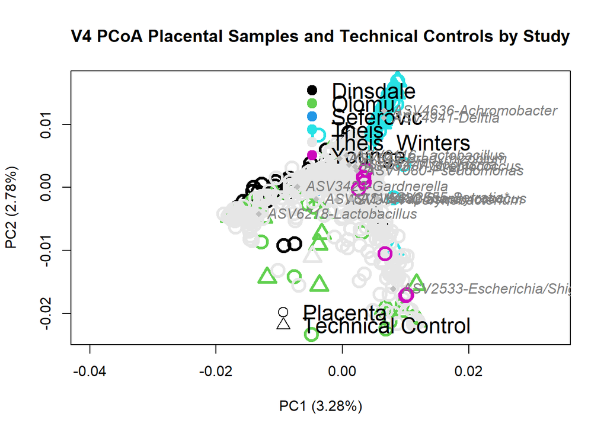

```r
#sets the palette for plotting
palette(c("black", "#61D04F", "#2297E6", "#28E2E5", "#e6e6e6", "#CD0BBC"))
#plots PCoA of placental samples with technical controls
S6_Beta_Plot_PTC <- beta_div(df = V4_ASV_PTC, df_meta = V4_META_PTC, taxa_on_rows = TRUE, type = "Study", study = "V4 PCoA Placental Samples and Technical Controls by Study", type2 = "Type", size = 2, legendyn = TRUE, Legend_Yspace = .5, inset = .18)
#characterizes ordination space with ASV genus level classifications
WA_labels(Plot_object = S6_Beta_Plot_PTC, ASV_table = V4_ASV_PTC, TAX_table = V4_TAX_PTC, ASVs_on_rows = TRUE, ASV_with_Genus = TRUE, color = "grey", Greater_than_1per = TRUE)
```

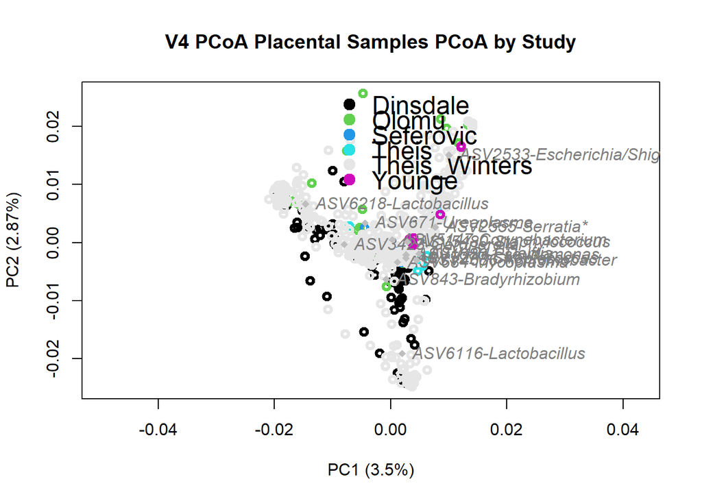

```r
#evaluates dispersion between sample types
#dispersion found to be significantly different
disp_V4_PTC_Type <- anova(betadisper(d = vegdist(t(V4_ASV_PTC), method = "bray"), group = V4_META_PTC$Type))

#performs analysis of variance between sample types using ADONIS (NPMANOVA). Samples are blocked by study.
#variance found to be non-significant
perm <- how(nperm = 999, blocks = with(V4_META_PTC, Study))
set.seed(1); adonis_V4_PTC_Type <- adonis2(formula = t(V4_ASV_PTC) ~ Type, data = V4_META_PTC, method = "bray", permutations = perm)

#sets the palette for plotting
palette(c("black", "#61D04F", "#2297E6", "#28E2E5", "#e6e6e6", "#CD0BBC"))
#plots PCoA of placental samples grouped by study
S6_Beta_Plot_P <- beta_div(df = V4_ASV_P, df_meta = V4_META_P, taxa_on_rows = TRUE, type = "Study", all_O = TRUE, study = "V4 PCoA Placental Samples PCoA by Study", legendyn = TRUE, inset = 0.2, Legend_Yspace = .5)
#characterizes ordination space with ASV genus level classifications
WA_labels(Plot_object = S6_Beta_Plot_P, ASV_table = V4_ASV_P, TAX_table = V4_TAX_P, ASVs_on_rows = TRUE, ASV_with_Genus = TRUE, color = "grey", Greater_than_1per = TRUE)
```

```r
#evaluates dispersion between sample types
#dispersion found to be significantly different
disp_V4_P_study <- anova(betadisper(d = vegdist(t(V4_ASV_P), method = "bray"), group = V4_META_P$Study))

#performs analysis of variance between sample types using ADONIS (NPMANOVA). Samples are blocked by study.
#variance found to be significantly different across studies
perm <- how(nperm = 999)
set.seed(1); adonis_V4_P_study <- adonis2(formula = t(V4_ASV_P) ~ Study, data = V4_META_P, method = "bray", permutations = perm);adonis_V4_P_study
```

```
## Permutation test for adonis under reduced model
## Terms added sequentially (first to last)
## Permutation: free
## Number of permutations: 999
##
## adonis2(formula = t(V4_ASV_P) ~ Study, data = V4_META_P, permutations = perm, method = "bray")
##           Df SumOfSqs      R2      F Pr(>F)
## Study      5   32.983 0.10474 16.005  0.001 ***
## Residual 684  281.917 0.89526
## Total    689  314.899 1.00000
## ---
## Signif. codes:  0 '***' 0.001 '**' 0.01 '*' 0.05 '.' 0.1 ' ' 1
```

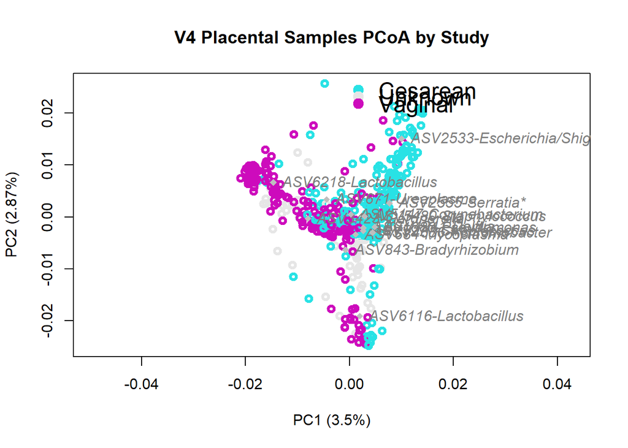

```r
#evaluates dispersion between technical controls grouped by study
#dispersion found to be significantly different
disp_V4_T_study <- anova(betadisper(d = vegdist(t(V4_ASV_T), method = "bray"), group = V4_META_T$Study))

#performs analysis of variance between sample types using ADONIS (NPMANOVA).
#variance found to be significantly different across studies
set.seed(1); adonis_V4_T_study <- adonis2(formula = t(V4_ASV_T) ~ Study, data = V4_META_T, permutations = 999, method = "bray")

#sets the palette for plotting
palette(c("#28E2E5", "#e6e6e6", "#CD0BBC"))
#plots PCoA of placental samples grouped by mode of delivery
S6_Beta_Plot_P_Del <- beta_div(df = V4_ASV_P, df_meta = V4_META_P, taxa_on_rows = TRUE, type = "Delivery", all_O = TRUE, study = "V4 Placental Samples PCoA by Study", legendyn = TRUE, inset = 0.2, Legend_Yspace = .25)
#characterizes ordination space with ASV genus level classifications
WA_labels(Plot_object = S6_Beta_Plot_P, ASV_table = V4_ASV_P, TAX_table = V4_TAX_P, ASVs_on_rows = TRUE, ASV_with_Genus = TRUE, color = "grey", Greater_than_1per = TRUE)
```

```r
#evaluates dispersion between placental samples grouped by delivery
#dispersion found to be significantly different
disp_V4P_del <- anova(betadisper(d = vegdist(t(V4_ASV_P), method = "bray"), group = V4_META_P$Delivery))

#performs analysis of variance between sample types (delivery) using ADONIS (NPMANOVA).
#significant differences between placental samples based on mode of delivery.
set.seed(1); adonis_pw_V4P_del_VC <- adonis2(formula = t(V4_ASV_P %>% select_if(V4_META_P$Delivery == "Cesarean" |V4_META_P$Delivery == "Vaginal")) ~ Delivery, data = V4_META_P %>% filter(Delivery == "Cesarean" | Delivery == "Vaginal"), permutations = 999, method = "bray");adonis_pw_V4P_del_VC
```

```
## Permutation test for adonis under reduced model
## Terms added sequentially (first to last)
## Permutation: free
## Number of permutations: 999
##
## adonis2(formula = t(V4_ASV_P %>% select_if(V4_META_P$Delivery == "Cesarean" | V4_META_P$Delivery == "Vaginal")) ~ Delivery, data = V4_META_P %>% filter(Delivery == "Cesarean" | Delivery == "Vaginal"), permutations = 999, method = "bray")
##           Df SumOfSqs      R2      F Pr(>F)
## Delivery   1    10.28 0.04272 23.877  0.001 ***
## Residual 535   230.34 0.95728
## Total    536   240.62 1.00000
## ---
## Signif. codes:  0 '***' 0.001 '**' 0.01 '*' 0.05 '.' 0.1 ' ' 1
```

## V4 Heatmaps by Study (Figure 6)

By visualizing ASV relative abundances across samples through heatmapping we can look closer at the ASVs which contribute to the clustering differences observed in the previous PCOA plots. Each of the following heatmaps is a panel in Figure 6.

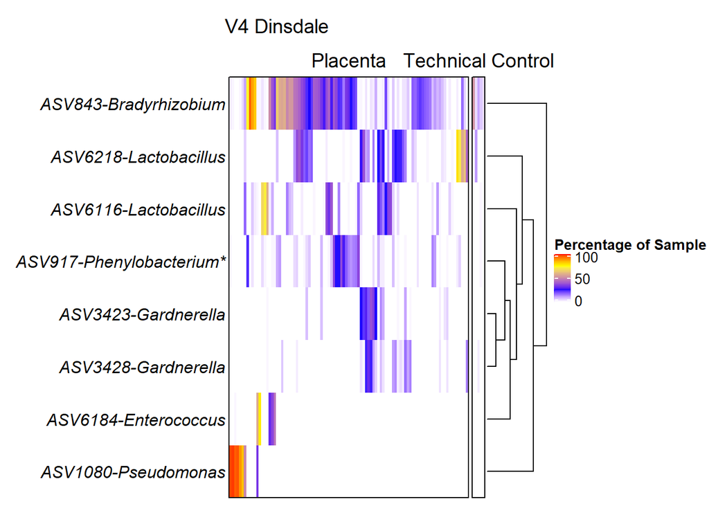

```r
#samples from each study which targeted the V4 16S hypervariable region is isolated
#taxonomy and metadata are updated by study
#ASVs in placental samples greater than 2% mean relative abundance are highlighted
#heatmaps are generated by study

V4_Dinsdale_ASV <- V4_ASV_PTC %>% select_if(V4_META_PTC$Study == "Dinsdale") %>% filter(rowSums(.) > 0)
V4_Dinsdale_TAX <- V4_TAX_PTC %>% filter(rownames(.) %in% rownames(V4_Dinsdale_ASV))
V4_Dinsdale_META <- V4_META_PTC %>% filter(Study == "Dinsdale")
V4_Dinsdale_ASVs <- top_ASVs_above_cutoff(ASV = V4_Dinsdale_ASV %>% select_if(V4_Dinsdale_META$Type == "Placenta"), TAX = V4_Dinsdale_TAX, cutoff = .02, top = 100, ASVs_on_Rows = TRUE, study = "Dinsdale")
V4_Dinsdale_heatprep <- heatmap_prep(df = V4_Dinsdale_ASV, df_tax = V4_Dinsdale_TAX, df_meta = V4_Dinsdale_META, class_col = "Genus", mean_ab_cutoff = FALSE, select_ASVs = V4_Dinsdale_ASVs$ASV)
heatmapping(df = V4_Dinsdale_heatprep, df_meta = V4_Dinsdale_META, types_col = "Type", scalecolor = "red-blue", title = "V4 Dinsdale")
```

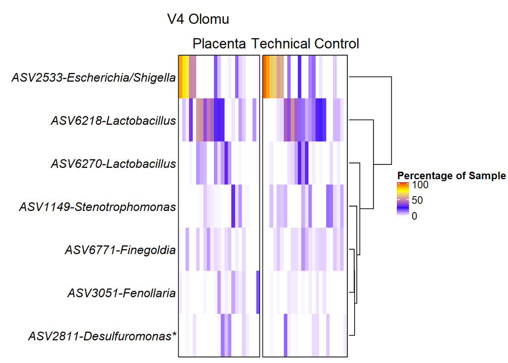

```r
V4_Olomu_ASV <- V4_ASV_PTC %>% select_if(V4_META_PTC$Study == "Olomu") %>% filter(rowSums(.) > 0)
V4_Olomu_TAX <- V4_TAX_PTC %>% filter(rownames(.) %in% rownames(V4_Olomu_ASV))
V4_Olomu_META <- V4_META_PTC %>% filter(Study == "Olomu")
V4_Olomu_ASVs <- top_ASVs_above_cutoff(ASV = V4_Olomu_ASV %>% select_if(V4_Olomu_META$Type == "Placenta"), TAX = V4_Olomu_TAX, cutoff = .02, top = 100, ASVs_on_Rows = TRUE, study = "Olomu")
V4_Olomu_heatprep <- heatmap_prep(df = V4_Olomu_ASV, df_tax = V4_Olomu_TAX, df_meta = V4_Olomu_META, class_col = "Genus", mean_ab_cutoff = FALSE, select_ASVs = V4_Olomu_ASVs$ASV)
heatmapping(df = V4_Olomu_heatprep, df_meta = V4_Olomu_META, types_col = "Type", scalecolor = "red-blue", title = "V4 Olomu")
```

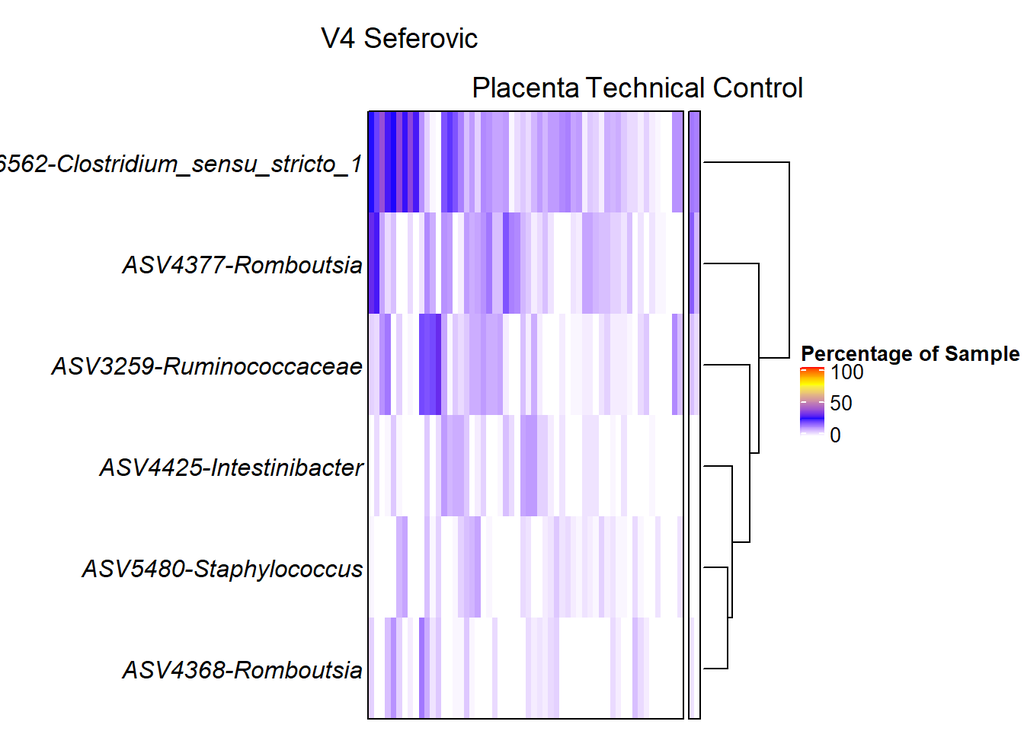

```r
V4_Seferovic_ASV <- V4_ASV_PTC %>% select_if(V4_META_PTC$Study == "Seferovic") %>% filter(rowSums(.) > 0)
V4_Seferovic_TAX <- V4_TAX_PTC %>% filter(rownames(.) %in% rownames(V4_Seferovic_ASV))
V4_Seferovic_META <- V4_META_PTC %>% filter(Study == "Seferovic")
V4_Seferovic_ASVs <- top_ASVs_above_cutoff(ASV = V4_Seferovic_ASV %>% select_if(V4_Seferovic_META$Type == "Placenta"), TAX = V4_Seferovic_TAX, cutoff = .02, top = 100, ASVs_on_Rows = TRUE, study = "Seferovic")
V4_Seferovic_heatprep <- heatmap_prep(df = V4_Seferovic_ASV, df_tax = V4_Seferovic_TAX, df_meta = V4_Seferovic_META, class_col = "Genus", mean_ab_cutoff = FALSE, select_ASVs = V4_Seferovic_ASVs$ASV)
heatmapping(df = V4_Seferovic_heatprep, df_meta = V4_Seferovic_META, types_col = "Type", scalecolor = "red-blue", title = "V4 Seferovic")
```

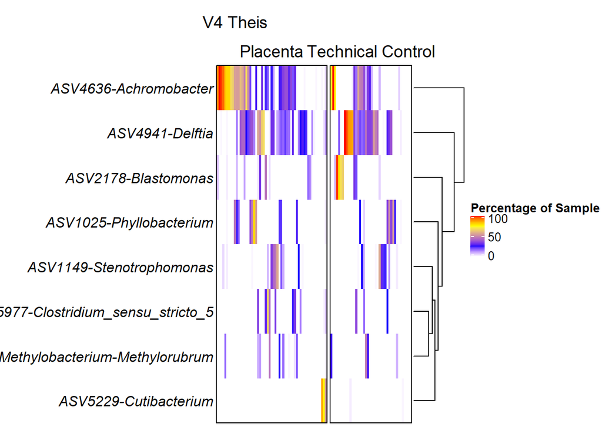

```r
V4_Theis_ASV <- V4_ASV_PTC %>% select_if(V4_META_PTC$Study == "Theis") %>% filter(rowSums(.) > 0)
V4_Theis_TAX <- V4_TAX_PTC %>% filter(rownames(.) %in% rownames(V4_Theis_ASV))
V4_Theis_META <- V4_META_PTC %>% filter(Study == "Theis")
V4_Theis_ASVs <- top_ASVs_above_cutoff(ASV = V4_Theis_ASV %>% select_if(V4_Theis_META$Type == "Placenta"), TAX = V4_Theis_TAX, cutoff = .02, top = 100, ASVs_on_Rows = TRUE, study = "Theis")
V4_Theis_heatprep <- heatmap_prep(df = V4_Theis_ASV, df_tax = V4_Theis_TAX, df_meta = V4_Theis_META, class_col = "Genus", mean_ab_cutoff = FALSE, select_ASVs = V4_Theis_ASVs$ASV)
heatmapping(df = V4_Theis_heatprep, df_meta = V4_Theis_META, types_col = "Type", scalecolor = "red-blue", title = "V4 Theis")
```

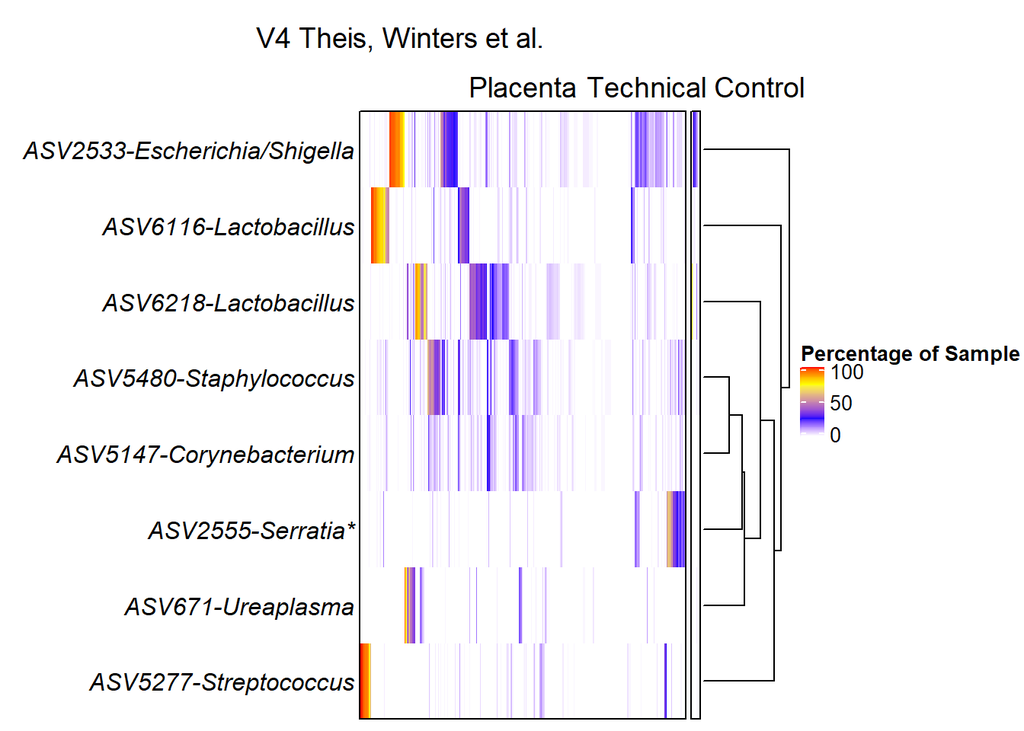

```r
V4_Theis_Winters_ASV <- V4_ASV_PTC %>% select_if(V4_META_PTC$Study == "Theis_Winters") %>% filter(rowSums(.) > 0)
V4_Theis_Winters_TAX <- V4_TAX_PTC %>% filter(rownames(.) %in% rownames(V4_Theis_Winters_ASV))
V4_Theis_Winters_META <- V4_META_PTC %>% filter(Study == "Theis_Winters")
V4_Theis_Winters_ASVs <- top_ASVs_above_cutoff(ASV = V4_Theis_Winters_ASV %>% select_if(V4_Theis_Winters_META$Type == "Placenta"), TAX = V4_Theis_Winters_TAX, cutoff = .02, top = 100, ASVs_on_Rows = TRUE, study = "Theis_Winters")
V4_Theis_Winters_heatprep <- heatmap_prep(df = V4_Theis_Winters_ASV, df_tax = V4_Theis_Winters_TAX, df_meta = V4_Theis_Winters_META, class_col = "Genus", mean_ab_cutoff = FALSE, select_ASVs = V4_Theis_Winters_ASVs$ASV)
heatmapping(df = V4_Theis_Winters_heatprep, df_meta = V4_Theis_Winters_META, types_col = "Type", scalecolor = "red-blue", title = "V4 Theis, Winters et al.")
```

```r
#lists ASVs greater than 1% mean relative abundance in technical controls from each study
#ASVs in heatmaps are modified in Inkscape with a red asterisk if greater than 2% mean relative abundance in placental samples and greater than 1% mean relative abundance in technical controls.
#Sample type titles are replaced in Inkscape with colored bars
V4_Studies_TC1_ASVs <- rbind(
  top_ASVs_above_cutoff(ASV = V4_Dinsdale_ASV %>% select_if(V4_Dinsdale_META$Type == "Technical Control"), TAX = V4_Dinsdale_TAX, cutoff = .01, ASVs_on_Rows = TRUE, study = "Dinsdale"),
  top_ASVs_above_cutoff(ASV = V4_Theis_Winters_ASV %>% select_if(V4_Theis_Winters_META$Type == "Technical Control"), TAX = V4_Theis_Winters_TAX, cutoff = .01, ASVs_on_Rows = TRUE, study = "Theis_Winters"),
  top_ASVs_above_cutoff(ASV = V4_Olomu_ASV %>% select_if(V4_Olomu_META$Type == "Technical Control"), TAX = V4_Olomu_TAX, cutoff = .01, ASVs_on_Rows = TRUE, study = "Olomu"),
  top_ASVs_above_cutoff(ASV = V4_Seferovic_ASV %>% select_if(V4_Seferovic_META$Type == "Technical Control"), TAX = V4_Seferovic_TAX, cutoff = .01, ASVs_on_Rows = TRUE, study = "Seferovic"),
  top_ASVs_above_cutoff(ASV = V4_Theis_ASV %>% select_if(V4_Theis_META$Type == "Technical Control"), TAX = V4_Theis_TAX, cutoff = .01, ASVs_on_Rows = TRUE, study = "Theis")
)
```

# Study-by-study analysis

## DADA2 pipeline details

Each study was processed following the 1.16 DADA2 tutorial found [online](https://benjjneb.github.io/dada2/tutorial.html). Profile plots were generated for both forward and reverse read files from each sample. Sequence quality along the length of the reads was evaluated and trim lengths were determined to maximize sequence length while maximizing the number of samples left in analysis with mean sequence quality greater than 30 across the entire trimmed sequence length. After merging sequences, the distribution of sequence lengths was inspected. From that, minimum and maximum sequence lengths were set (e.g. `seqtab2 <- seqtab[,nchar(colnames(seqtab)) %in% 324:362]`) and `seqtab2` was used in place of `seqtab` in following lines of code. To help with analysis, `seqtab.nochim` was transposed with `t()` (e.g. `seqtab.nochim.t <- t(seqtab.nochim)`). A DADA2 formatted Silva v138 [database](https://zenodo.org/record/3731176#.YZgeObpOmM8) was used to classify ASVs and species assignment was attempted using the species database from the same website. Finally, `seqtab.nochim.t` was merged with the taxonomy object after species level assignment with `merged <- cbind(taxa, seqtab.nochim.t)` and the image and history were saved with `save.image()` and `savehistory()`. The `merged` object was saved as a `merged.csv` for future analysis wtih `write.csv(merged, file = "merged.csv")`. RPushbullet was used for notifications. The [link](https://github.com/eddelbuettel/rpushbullet) to github for `RPushbullet` setup.

## Study specific changes

de Goffau - On the SRA run database the report of sample metadata is available for download as a `.tsv`. Select `Sample Accession`, `Secondary Sample Accession`, and `Run Accession` to utilize for the data cleaning. File generated was saved as `deGoffau_ERR-ERS.tsv`.

Gomez-Arango - Publicly available samples were already merged forward and reverse reads.

Leon - Samples needed to be demultiplexed:

Sequences within fastq files are named as such: `@ERR2531248.1 P254_0 length=369` In order to split sequences into individual files based on their sample name, we first have to remove the ERR numbers so that they look like so: `@P254_0 length=369`

This is accomplished by running a line of sed code for each file with sed (GNU sed) version 4.2.1 (2009) from a linux terminal (QIIME image 1.9.1 was used): `sed ‘s/ERR[[:digit:]]\+.[[:digit:]]\+\s//g’ Input.fastq > Output.fastq`

After installing the QIIME scripts (installation instructions found at: [QIIME Scripts](http://qiime.org/scripts/) ), split_sequence_file_on_sample_ids.py was used to partition sequences into individual sample files. `split_sequence_file_on_sample_ids.py -i input.fastq -o output_dir --file_type fastq`

Liu - Additional Liu_Metadata2.xlsx file found as supplementary materials at [link](https://www.sciencedirect.com/science/article/pii/S2352396419307157#sec0022)

Tang - Paper lists accession as SRA958249 but actual accession is listed in the table below.

```r
#creates data frame which tabulates all the study specific changes to the DADA2 processing pipeline
Study_changes <- data.frame(deGoffau = c("_1.fastq", "_2.fastq", "(245,235)", "independent", "324:362"), Dinsdale = c("_1.fastq", "_2.fastq", "(230,215)", "pooled", "252:276"), `Gomez-Arango` = c(".fastq", NA, "230", "pooled", "229:231"), Lauder = c(".fastq", NA, "320", "pooled", NA), Leiby = c("_1.fastq", "_2.fastq", "(200,170)", "pooled", "298:332"), Leon = c(".fastq", NA, "360", "pooled", NA), Liu = c("_1.fastq", "_2.fastq", "(270,200)", "pooled", "398:414"), Olomu = c("_1.fastq", "_2.fastq", "(235:220)", "pooled", "252:287"), Parnell = c("_1.fastq", "_2.fastq", "(145,140)", "pooled", "164:190"), Seferovic = c("_1.fastq", "_2.fastq", "(245,230)", "pooled", "267:308"), Sterpu = c("_1.fastq", "_2.fastq", "(270,240)", "pooled", "430:440"), Tang = c("_1.fastq", "_2.fastq", "(290,250)", "pooled", "440:471"), Theis = c("_1.fastq", "_2.fastq", "(240,200)", "pooled", "252:272"), Younge = c("_1.fastq", "_2.fastq", "(240,200)", "pooled", "251:272"), Theis_Winters = c("_R1.fastq", "_R2.fastq", "(210, 100)", "pooled", "252:254"), row.names = c("Forward File Pattern", "Reverse File Pattern", "Truncation Lengths (F,R)", "DADA2 Method", "Merged Read Cutoffs (min:max)"))

#creates dataframe with study data
Study_table <- data.frame(deGoffau = c("ERP109246"), Dinsdale = c("PRJEB39698"), `Gomez-Arango` = c("PRJNA357524"), Lauder = c("PRJNA309332"), Leiby = c("PRJNA451186"), Leon = c("PRJEB25986"), Liu = c("PRJNA559967"), Olomu = c("PRJNA577959"), Parnell = c("PRJNA395716"), Seferovic = c("PRJNA511648"), Sterpu = c("PRJEB38528"), Tang = c("PRJNA564455"), Theis = c("PRJNA397876"), Younge = c("PRJNA557826"), row.names = c("Project Number"))
```

## de Goffau et al. analysis

### de Goffau et al. data cleaning

Here we filter metadata to samples which pass quality filtering and remove ASVs which correspond to Salmonella bongori, which was spiked into every sample.

```r
#loads DADA2 processed ASV count table and taxonomy merged together
de_Goffau_merged <- read.csv(file = "deGoffau_merged.csv", stringsAsFactors = FALSE)
#loads metadata associated with study and renames first column as `ERS`
de_Goffau_meta <- read.xlsx(xlsxFile = "deGoffau Supplementary Information File 2 Updated.xlsx", sheet = "ENA link", startRow = 1066, colNames = TRUE); colnames(de_Goffau_meta)[1] <- c("ERS")
#metadata in supplementary corresponds to ERS numbers but ASV count data corresponds to ERR numbers so we need a key to match the data. keeps last two columns and renames them
dg_sra_key <- read.table(file = "deGoffau_ERR_to_ERS.tsv", sep = "\t", stringsAsFactors = FALSE, header = TRUE); dg_sra_key <- dg_sra_key[,2:3]; colnames(dg_sra_key) <- c("ERS", "Run")
#merges key and metadata by ERS column
dg_meta_merged <- merge(de_Goffau_meta, dg_sra_key, by = "ERS", sort = FALSE)

#since all samples were spiked with Salmonella bongori we need to remove these ASVs.
#First we filter the merged dataset to only those in the order Enterobacterales. Then we get the exact sequences along with the order classification
merged_only_Entero <- de_Goffau_merged %>% filter(Order == "Enterobacterales"); dg_seqs <- merged_only_Entero$X; dg_names <- merged_only_Entero$Order
#queries local NCBI blast database to get finer classification
#blaster can be problematic if the terminal does not recognize the escape backslashes for the quotes
#if this happens we read in the results if the function had worked
Enterobacterales_unclassified_results <- tryCatch(
  {
    blaster(seqs = dg_seqs, names = dg_names)
  },
  error = function(cond){
    message(cond)
    blasted <- read.table(file = "Blasted.tsv", "\t")
    colnames(blasted) <- c("Query Seq ID", "Expect value",
                           "Bitscore", "Subject TAX ID", "Percent Identical",
                           "Query Coverage", "Subject Title")
    return(blasted)
  }
)
#determines which Enterobacterales were not classifed as Salmonella
non_salmonella_Enterobacterales <- Enterobacterales_unclassified_results %>% filter(substr(`Subject Title`, 1, 6) != "Salmon")
#prepares replacement classification at genus level
entero_replace <- sapply(strsplit(Enterobacterales_unclassified_results$`Subject Title`, " "), `[`, 1)
#replaces genus classifcations of ASVs classified as Enterobacterales with local blast results
dg_merged_classified <- de_Goffau_merged %>% mutate(Genus = ifelse(Order == "Enterobacterales", entero_replace, de_Goffau_merged$Genus))
#filters ASVs classifed as Salmonella
dg_merged_no_Sbon <- dg_merged_classified %>% filter(Genus != "Salmonella")

#cleans sequence data, adds blank species column next to rest of taxonomy, and renames rows with numbered ASVs
de_Goffau_merged_clean <- as.data.frame(dadaset_clean(dg_merged_no_Sbon, read_thresh = 100)); de_Goffau_merged_clean$Species <- NA; de_Goffau_merged_clean <- de_Goffau_merged_clean[,c(1:7, 130, 8:129)]
```

```
## Originally there were 14856 taxa.
##  0 were not bacterial or classified at phylum level.
##  0 were mitochondrial. 0 were chloroplast.
##  14856 taxa remain. 0 samples eliminated with less than 100 reads:
```

```r
rownames(de_Goffau_merged_clean) <- paste0("ASV", 1:nrow(de_Goffau_merged_clean))

#filters metadata to samples which remain after cleaning
deGoffau_META <- dg_meta_merged %>% filter(Run %in% colnames(de_Goffau_merged_clean)[9:ncol(de_Goffau_merged_clean)])
#recodes `type` metadata
deGoffau_META$Type <- case_when(
    deGoffau_META$status == "SGA" ~ "Placenta",
    deGoffau_META$status == "CTRL" ~ "Placenta",
    deGoffau_META$status == "PE" ~ "Placenta",
    is.na(deGoffau_META$status) ~ "Technical Control"
)
#splits merged sequence data into an `ASV` count table and a taxonomy `TAX` object.
deGoffau_ASV <- de_Goffau_merged_clean[,9:ncol(de_Goffau_merged_clean)]; deGoffau_TAX <- de_Goffau_merged_clean[,1:8]
```

### de Goffau et al. Normalization

Normalization is needed for placental samples due to the great variance in sampling depth

```r
#visualization of sampling depth variance across dataset
table(colSums(deGoffau_ASV))
```

```
##
##  5929  6036  6390  6417  6484  6640  7510  8452  8706  8772  9204  9883 10124
##     1     1     1     1     1     1     1     1     1     1     1     1     1
## 10156 10248 10419 10691 10978 11018 11409 11954 12227 12366 12411 12475 12538
##     1     1     1     1     1     1     1     1     1     1     1     1     1
## 12568 12655 12763 12845 12947 12955 13009 13241 13318 13393 13475 13530 13629
##     1     1     1     1     1     1     1     1     1     1     1     1     1
## 13669 13974 14054 14222 14268 14386 14404 14524 14683 14705 14810 14916 15093
##     1     1     1     1     1     1     1     1     1     2     1     1     1
## 15243 15489 15618 15737 15929 16193 16477 16563 16612 16946 16986 17072 17117
##     1     1     1     1     1     1     1     1     1     1     1     1     1
## 17279 17478 17577 17667 17749 17872 17972 18049 18160 18185 18533 18660 19009
##     1     1     1     1     1     1     1     1     1     1     1     1     1
## 19188 19422 19467 19497 19684 19803 19932 20104 20357 20621 21020 21067 21165
##     1     1     1     1     1     1     1     1     1     1     1     1     1
## 21295 22043 22224 22602 22704 22890 23437 24335 24409 24560 24794 25375 26729
##     1     1     1     1     1     1     1     1     1     1     1     1     1
## 26934 27827 28583 28791 29087 31233 31342 31692 31761 32454 32571 33420 35659
##     1     1     1     1     1     1     1     1     1     1     1     1     1
## 37497 37640 37676 46621
##     1     1     1     1
```

```r
#converts dataset to phyloseq object
phy <- phyloseqize(merged_df = deGoffau_ASV, taxa_as_rows = TRUE, keep_ASV_nums = TRUE, tax_df = deGoffau_TAX)
#normalizes samples to the greater of either the minimum number of sequences per sample in a dataset or 100. Samples with less than 100 sequences at this point are removed.
rarefied <- rarefy_even_depth(physeq = phy, sample.size = max(min(sample_sums(phy)), 100), rngseed = 1, replace = FALSE)
```

```
## `set.seed(1)` was used to initialize repeatable random subsampling.
```

```
## Please record this for your records so others can reproduce.
```

```
## Try `set.seed(1); .Random.seed` for the full vector
```

```
## ...
```

```
## 1574OTUs were removed because they are no longer
## present in any sample after random subsampling
```

```
## ...
```

```r
#converts phyloseq object back to merged data frame
merged_rare <- dephy(rarefied)
#splits dataframe into `ASV` count table, `TAX` taxonomy, and ensures that metadata is current with remaining samples.
deGoffau_rare_ASV <- merged_rare[,9:ncol(merged_rare)]; deGoffau_rare_TAX <- merged_rare[,1:8]; deGoffau_rare_META <- deGoffau_META %>% filter(Run %in% colnames(deGoffau_rare_ASV))
```

### de Goffau et al. PTCWA PCoA

Code for Figure 3F

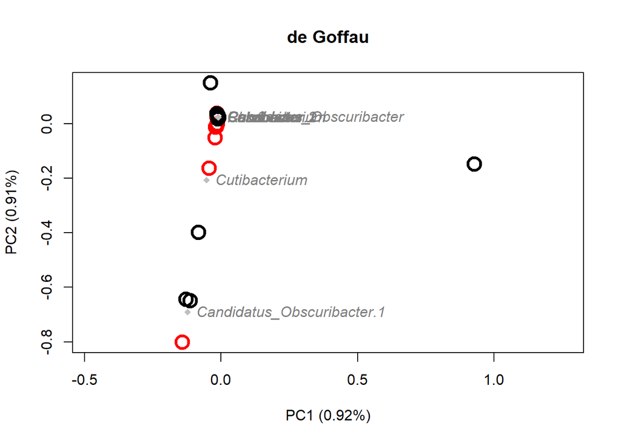

```r
#Figure 1.3F
#allows plotting which extends past plot window
par(xpd = FALSE)
#sets palette
palette(c("red", "black"))
#plots PCoA of placental samples contrasted with technical controls
deGoffau_Beta_plot_PTC <- beta_div(df = deGoffau_rare_ASV, df_meta = deGoffau_rare_META, type = "Type", study = "de Goffau", all_O = TRUE, taxa_on_rows = TRUE, size = 2, legendyn = FALSE, ASP = 1)
#gets top ten ranked ASVs by mean relative abundance in the dataset
deGoffau_topASVs <- rowSums(deGoffau_rare_ASV) %>% sort(., decreasing = TRUE) %>% head(., 10)
#characterizes ordination space with ASV genus level classifications
WA_labels(Plot_object = deGoffau_Beta_plot_PTC, ASV_table = deGoffau_rare_ASV, TAX_table = deGoffau_rare_TAX, ASVs_on_rows = TRUE, ASV_with_Genus = FALSE, Tax_col = "Genus", color = "grey", Greater_than_1per = FALSE, ASVs_to_plot = names(deGoffau_topASVs))
```

## Dinsdale et al. analysis

### Dinsdale et al. data cleaning

Data was already filtered and cleaned in V4 subset section.

```r
#removes ASV column
Dinsdale_TAX <- Dinsdale_TAX[,-1]
```

### Dinsdale et al. subsets pre-DECONTAM

```r
#subsets metadata to only placental samples and technical controls.
DinsdaleD_META_PTC <- Dinsdale_META %>% filter(Type == "Placenta" | Type == "Technical Control")
#subsets ASV count table to samples remaining in metadata and removes ASVs which no longer have reads remaining in the dataset
DinsdaleD_ASV_PTC <- Dinsdale_ASV %>% select_if(colnames(.) %in% DinsdaleD_META_PTC$Run); DinsdaleD_ASV_PTC <- DinsdaleD_ASV_PTC %>% filter(rowSums(.) > 0)
#filters taxonomy to match remaining ASVs in ASV count table
DinsdaleD_TAX_PTC <- Dinsdale_TAX %>% filter(rownames(.) %in% rownames(DinsdaleD_ASV_PTC))
```

### Dinsdale et al. DECONTAM

Removes likely contaminants.

```r
#DECONTAM requires a column indicating which samples are to be considered samples and which are controls
DinsdaleD_META_PTC$Deco_type <- case_when(DinsdaleD_META_PTC$Type == "Placenta" ~ "sample", DinsdaleD_META_PTC$Type == "Technical Control" ~ "control")
#prepares data for DECONTAM
Dinsdale_DECO_prep <- decontam_prep(df = cbind(DinsdaleD_TAX_PTC, DinsdaleD_ASV_PTC), meta = DinsdaleD_META_PTC, type = "Deco_type", sample_col = "Run")
#generates histogram and prevalence plots comparing ASVs by prevalence in samples vs. controls
DECO_plots_Dinsdale <- decontam_histo_prev_plots(physeq = Dinsdale_DECO_prep, thresh = 0.2, study_name = "Dinsdale")
```

```
## [1] "True represents true taxa:"
##
## FALSE  TRUE
##  1136    67
```

```r
#removes likely contaminants with a threshold of 0.2
Dinsdale_decontaminated <- decontaminate(df = cbind(DinsdaleD_TAX_PTC, DinsdaleD_ASV_PTC), physeq = Dinsdale_DECO_prep, thresh = 0.2)
#returns taxa considered to be truly in the sample
Dinsdale_true_taxa <- Dinsdale_decontaminated$TrueTaxa
```

### Dinsdale et al. normalization

Normalizes both pre-DECONTAM dataset and dataset post-DECONTAM

```r
#pre-DECONTAM dataset normalization
#visualization of sampling depth variance across dataset
table(colSums(Dinsdale_ASV))
```

```
##
##    131    179    575   2331   4205   7525  10293  11795  13278  13404  14845
##      1      1      1      1      1      1      1      1      1      1      1
##  15422  15730  15947  15977  16154  16795  17466  18130  18716  19346  19508
##      1      1      1      1      1      1      1      1      1      1      1
##  19616  21753  22187  23556  24711  26043  26318  26986  27601  28336  28511
##      1      1      1      1      1      1      1      1      1      1      1
##  28799  29603  29958  30862  31007  31518  32493  33199  34277  34285  34286
##      1      1      1      1      1      1      1      1      1      1      1
##  34743  34783  34973  36489  36768  36781  37177  37290  37546  38743  39283
##      1      1      1      1      1      1      1      1      1      1      1
##  41440  41551  43403  44056  44639  44683  44855  45718  46425  46501  46960
##      1      1      1      1      1      1      1      1      1      1      1
##  50390  50574  51383  52641  53020  55581  55718  56223  56835  57253  57770
##      1      1      1      1      1      1      1      1      1      1      1
##  58193  58438  59564  60722  63497  64098  65118  65203  65362  66658  66728
##      1      1      1      1      1      1      1      1      1      1      1
##  67053  68262  69710  76029  76103  78899  79931  80805  82660  83405  86478
##      1      1      1      1      1      1      1      1      1      1      1
##  92822  97701 102430 105787 105992 110136 114805 115198 115288 117753 122778
##      1      1      1      1      1      1      1      1      1      1      1
## 123290 123427 123490 126033 132271 132326 135883 136551 138862 140573 140959
##      1      1      1      1      1      1      1      1      1      1      1
## 145157 146739 151106 151802 155639 163062 163224 164568 165056 165146 168577
##      1      1      1      1      1      1      1      1      1      1      1
## 168849 175341 177500 179888 188047 189881 190018 192146 199709 203720 210089
##      1      1      1      1      1      1      1      1      1      1      1
## 210445 212145 219568 220135 223043 235042 238724 861621
##      1      1      1      1      1      1      1      1
```

```r
#converts dataset to phyloseq object
phy <- phyloseqize(merged_df = Dinsdale_ASV, taxa_as_rows = TRUE, keep_ASV_nums = TRUE, tax_df = Dinsdale_TAX)
#normalizes samples to the greater of either the minimum number of sequences per sample in a dataset or 100. Samples with less than 100 sequences at this point are removed.
rarefied <- rarefy_even_depth(physeq = phy, sample.size = max(min(sample_sums(phy)), 100), rngseed = 1, replace = FALSE)
```

```
## `set.seed(1)` was used to initialize repeatable random subsampling.
```

```
## Please record this for your records so others can reproduce.
```

```
## Try `set.seed(1); .Random.seed` for the full vector
```

```
## ...
```

```
## 827OTUs were removed because they are no longer
## present in any sample after random subsampling
```

```
## ...
```

```r
#converts phyloseq object back to merged data frame
merged_rare <- dephy(rarefied)
#splits dataframe into `ASV` count table, `TAX` taxonomy, and ensures that metadata is current with remaining samples.
Dinsdale_rare_ASV <- merged_rare[,9:ncol(merged_rare)]; Dinsdale_rare_TAX <- merged_rare[,1:8]; Dinsdale_rare_META <- Dinsdale_META %>% filter(Run %in% colnames(Dinsdale_rare_ASV))

#post-DECONTAM dataset normalization
#visualization of sampling depth variance across dataset
table(colSums(Dinsdale_true_taxa[,9:ncol(Dinsdale_true_taxa)]))
```

```
##
##      1     19     23     25     32     43     50     55     56     84    103
##      1      1      1      1      1      1      1      1      1      1      1
##    159    221    274    407    541    590    633    959   1175   1436   1631
##      1      1      1      1      1      1      1      1      1      1      1
##   2208   2221   2243   2244   2520   2795   3274   3492   3521   3525   3532
##      1      1      1      1      1      1      1      1      1      1      1
##   3654   4180   4260   4453   4544   5350   5893   5971   6774   6817   7146
##      1      1      1      1      1      1      1      1      1      1      1
##   7701   8109   8837   8926   9148   9875  10106  11236  11866  11891  12121
##      1      1      1      1      1      1      1      1      1      1      1
##  12230  12473  13059  14292  15236  15380  15760  15982  16326  16850  17288
##      1      1      1      1      1      1      1      1      1      1      1
##  19128  20158  21168  21374  21652  22725  24885  25121  26197  27012  27110
##      1      1      1      1      1      1      1      1      1      1      1
##  27949  29767  30600  35226  44071  44780  46260  46717  48877  53375  58132
##      1      1      1      1      1      1      1      1      1      1      1
##  63805  70566  70722  71309  75761  83509  87953 100127 106295 113494 121890
##      1      1      1      1      1      1      1      1      1      1      1
## 143831 201199 219989
##      1      1      1
```

```r
#converts dataset to phyloseq object
phy <- phyloseqize(cbind(Dinsdale_true_taxa[,1:8], Dinsdale_true_taxa[,9:ncol(Dinsdale_true_taxa)]))
#normalizes samples to the greater of either the minimum number of sequences per sample in a dataset or 100. Samples with less than 100 sequences at this point are removed.
rarefied <- rarefy_even_depth(physeq = phy, sample.size = max(min(sample_sums(phy)), 100), rngseed = 1, replace = FALSE)
```

```
## `set.seed(1)` was used to initialize repeatable random subsampling.
```

```
## Please record this for your records so others can reproduce.
```

```
## Try `set.seed(1); .Random.seed` for the full vector
```

```
## ...
```

```
## 10 samples removedbecause they contained fewer reads than `sample.size`.
```

```
## Up to first five removed samples are:
```

```
## ERR4403666ERR4403669ERR4403670ERR4403672ERR4403673
```

```
## ...
```

```
## 3OTUs were removed because they are no longer
## present in any sample after random subsampling
```

```
## ...
```

```r
#converts phyloseq object back to merged data frame
merged_rare <- dephy(rarefied)
```

### Dinsdale et al. post-normalization subsets

Top ranked ASVs are determined in placental smaples from pre- and post-DECONTAM datsets.

```r
#post-DECONTAM dataset after normalization does not need technical controls
DinsdaleD_rare_META <- DinsdaleD_META_PTC %>% filter(Run %in% colnames(merged_rare[,9:ncol(merged_rare)]) & Type == "Placenta")
#splits dataframe into `ASV` count table, `TAX` taxonomy
DinsdaleD_rare_ASV <- merged_rare[,9:ncol(merged_rare)]; DinsdaleD_rare_TAX <- merged_rare[,1:8]
#removes technical controls from `ASV` count table and removes ASVs no longer present in samples
DinsdaleD_rare_ASV <- DinsdaleD_rare_ASV %>% select_if(colnames(.) %in% DinsdaleD_rare_META$Run); DinsdaleD_rare_ASV <- DinsdaleD_rare_ASV %>% filter(rowSums(.) > 0)
#keeps taxonomy current with count table.
DinsdaleD_rare_TAX <- DinsdaleD_rare_TAX %>% filter(rownames(.) %in% rownames(DinsdaleD_rare_ASV))
#stores top five ranked ASVs by mean relative abundance in post-DECONTAM dataset
Top5_Dinsdale_DECO <- top_ASVs_above_cutoff(ASV = DinsdaleD_rare_ASV, TAX = DinsdaleD_rare_TAX, cutoff = 0.01, top = 5, ASVs_on_Rows = TRUE, study = "Dinsdale")

#pre-DECONTAM subsets
#selects placental samples and technical controls and removes ASVs no longer in the dataset
Dinsdale_ASV_PTC <- Dinsdale_rare_ASV %>% select_if(Dinsdale_rare_META$Type == "Placenta" | Dinsdale_rare_META$Type == "Technical Control"); Dinsdale_ASV_PTC <- Dinsdale_ASV_PTC %>% filter(rowSums(.) > 0)
#updates metadata and taxonomy to match ASV count table
Dinsdale_TAX_PTC <- Dinsdale_rare_TAX %>% filter(rownames(.) %in% rownames(Dinsdale_ASV_PTC)); Dinsdale_META_PTC <- Dinsdale_rare_META %>% filter(Run %in% colnames(Dinsdale_ASV_PTC))

#selects placental samples and removes ASVs no longer in the dataset
Dinsdale_ASV_P <- Dinsdale_rare_ASV %>% select_if(Dinsdale_rare_META$Type == "Placenta"); Dinsdale_ASV_P <- Dinsdale_ASV_P %>% filter(rowSums(.) > 0)
#updates metadata and taxonomy to match ASV count table
Dinsdale_TAX_P <- Dinsdale_rare_TAX %>% filter(rownames(.) %in% rownames(Dinsdale_ASV_P)); Dinsdale_META_P <- Dinsdale_rare_META %>% filter(Run %in% colnames(Dinsdale_ASV_P))
#stores top five ranked ASVs by mean relative abundance in pre-DECONTAM placental samples dataset
Top5_Dinsdale <- top_ASVs_above_cutoff(ASV = Dinsdale_ASV_P, TAX = Dinsdale_TAX_P, cutoff = 0.01, top = 5, ASVs_on_Rows = TRUE, study = "Dinsdale")
```

### Dinsdale et al. PCoAs

Code for Figures 3D and 4D

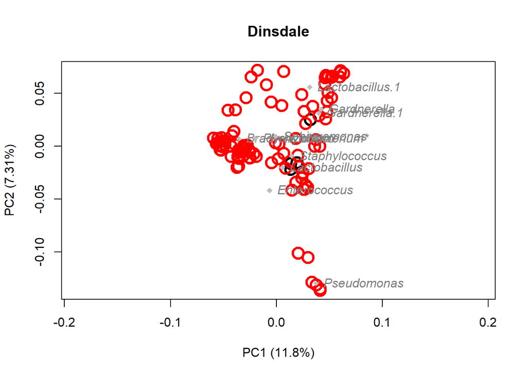

```r
#Figure 3D Placental Samples/Technical Controls
#allows plotting which extends past plot window
par(xpd = FALSE)
#sets palette
palette(c("red", "black"))
#plots PCoA of placental samples contrasted with technical controls
Dinsdale_Beta_plot_PTCWA <- beta_div(df = Dinsdale_ASV_PTC, df_meta = Dinsdale_META_PTC, type = "Type", study = "Dinsdale", all_O = TRUE, taxa_on_rows = TRUE, size = 2, legendyn = FALSE)
#returns top ten ranked ASVs by mean relative abundance in the dataset
Dinsdale_topASVs <- rowSums(Dinsdale_ASV_PTC) %>% sort(., decreasing = TRUE) %>% head(., 10)
#characterizes ordination space with ASV genus level classifications
WA_labels(Plot_object = Dinsdale_Beta_plot_PTCWA, ASV_table = Dinsdale_ASV_PTC, TAX_table = Dinsdale_TAX_PTC, ASVs_on_rows = TRUE, ASV_with_Genus = FALSE, Tax_col = "Genus", color = "grey", Greater_than_1per = FALSE, ASVs_to_plot = names(Dinsdale_topASVs))
```

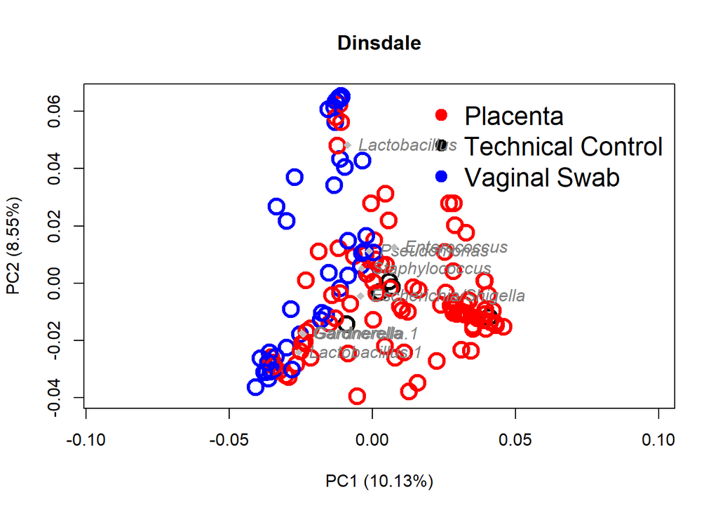

```r
#Figure 4D Placental Samples/Technical Controls/Vaginal Swabs
#allows plotting which extends past plot window
par(xpd= FALSE)
#sets palette
palette(c("red", "black", "blue"))
#plots PCoA of placental samples contrasted with technical controls and vaginal swabs
Dinsdale_Beta_plot_PTCVWA <- beta_div(df = Dinsdale_rare_ASV, df_meta = Dinsdale_rare_META, type = "Type", study = "Dinsdale", all_O = TRUE, taxa_on_rows = TRUE, size = 2)
#returns top ten ranked ASVs in placental samples and technical controls
Dinsdale_top10ASV_PTC <- rowSums(Dinsdale_rare_ASV) %>% sort(., decreasing = TRUE) %>% head(., 10)
#returns top ten ranked ASVs in vaginal swab samples
Dinsdale_top10ASV_V <- rowSums(Dinsdale_rare_ASV %>% select_if(Dinsdale_rare_META$Type == "Vaginal Swab")) %>% sort(., decreasing = TRUE) %>% head(., 10)
#returns shared ASVs between the sample types
Dinsdale_top10shared <- Dinsdale_top10ASV_PTC[names(Dinsdale_top10ASV_PTC) %in% names(Dinsdale_top10ASV_V)]
#characterizes ordination space with ASV genus level classifications
WA_labels(Plot_object = Dinsdale_Beta_plot_PTCVWA, ASV_table = Dinsdale_rare_ASV, TAX_table = Dinsdale_rare_TAX, ASVs_on_rows = TRUE, ASV_with_Genus = FALSE, Tax_col = "Genus", color = "grey", Greater_than_1per = FALSE, ASVs_to_plot = names(Dinsdale_top10shared))
```

## Gomez-Arango et al. analysis

### Gomez-Arango et al. data cleaning

Data is cleaned.

```r
#loads DADA2 processed ASV count table and taxonomy merged together
GA_merged <- read.csv("GomezArango_merged.csv", stringsAsFactors = FALSE)
#Loads metadata
GA_meta <- read.csv(file = "GomezArango_SraRunTable.csv", stringsAsFactors = FALSE)
#cleans sequence data and renames rows with numbered ASVs
GA_merged_clean <- dadaset_clean(GA_merged, read_thresh = 100); rownames(GA_merged_clean) <- paste0("ASV", 1:nrow(GA_merged_clean))
```

```
## Originally there were 7078 taxa.
##  2283 were not bacterial or classified at phylum level.
##  4 were mitochondrial. 19 were chloroplast.
##  4772 taxa remain. 2 samples eliminated with less than 100 reads: SRR5121593 SRR5121654
```

```r
#splits merged sequence data into an `ASV` count table and a taxonomy `TAX` object. In order to merge the studies later on, the `TAX` object needs to have an ASV column with numbered ASVs.
Gomez_Arango_ASV <- GA_merged_clean[,9:ncol(GA_merged_clean)]; Gomez_Arango_TAX <- GA_merged_clean[,1:8]

#selects columns from metadata
Gomez_Arango_META <- GA_meta %>% select_if(colnames(.) %in% c("Run", "Sample.Name", "Tissue"))
#`Sample.Name` column split into `Subject ID` and `Source` columns
Gomez_Arango_META$Subject_ID <- sub(pattern = "(\\D+)(_)(\\d*)", x = Gomez_Arango_META$Sample.Name, replacement = "\\3"); Gomez_Arango_META$Source <- sub(pattern = "(\\D+)(_)(\\d*)", x = Gomez_Arango_META$Sample.Name, replacement = "\\1")
#`Type` column generated from `Tissue` and `Source` columns
Gomez_Arango_META <- Gomez_Arango_META %>% mutate(Type = paste(Tissue, Source, sep = " "))
#filters metadata to samples left in ASV count table
Gomez_Arango_META <- Gomez_Arango_META %>% filter(Run %in% colnames(Gomez_Arango_ASV))

#Reclassifies ASV186 Lactobacillales which shares 99.13% identity to multiple type strains of Lactobacillus
Gomez_Arango_TAX$Genus[match("ASV186", rownames(Gomez_Arango_TAX))] <- "Lactobacillus*"
#Reclassifies ASV96 Pseudomonadaceae which shares 99.57% identity to multiple type strains of Pseudomonas
Gomez_Arango_TAX$Genus[match("ASV96", rownames(Gomez_Arango_TAX))] <- "Pseudomonas*"
#Reclassifies ASV33 Lactobacillales which shares 99.13% identity to multiple type strains of Lactobacillus
Gomez_Arango_TAX$Genus[match("ASV33", rownames(Gomez_Arango_TAX))] <- "Lactobacillus*"
```

### Gomez-Arango et al. normalization

Normalizes data.

```r
#visualization of sampling depth variance across dataset
table(colSums(Gomez_Arango_ASV))
```

```
##
##    107    110    123    162    187    195    235    238    253    254    282
##      1      1      1      1      1      1      1      1      1      1      1
##    284    290    306    316    320    327    364    386    430    431    464
##      1      1      1      1      1      1      1      1      1      1      1
##    676    687    707    760   1277   1437   1501   3547  10227  13827  14134
##      1      1      1      3      1      1      1      1      1      1      1
##  15792  17130  17973  18015  18450  18470  19099  19990  20248  23253  23988
##      1      1      1      1      1      1      1      1      1      1      1
##  24084  24273  24634  24954  25044  26040  26182  26492  26635  26828  27011
##      1      1      1      1      1      1      1      1      1      1      1
##  27106  27429  28359  28464  29740  30869  31403  31802  32503  32834  34320
##      1      1      1      1      1      1      1      1      1      1      1
##  35007  36217  38012  38352  38890  39647  43060  45464  46333  46351  47723
##      1      1      1      1      1      1      1      1      1      1      1
##  47924  48850  49296  49548  51618  51778  52144  53004  53293  54119  54852
##      1      1      1      1      1      1      1      1      1      1      1
##  54874  55196  56376  56925  56993  57109  57140  57252  57306  57956  58274
##      1      1      1      1      1      1      1      1      1      1      1
##  58311  59847  60685  60782  62716  63656  64875  66761  68489  69265  70259
##      1      1      1      1      1      1      1      1      1      1      1
##  72807  74414  77540  82915  97002 110347 121323 126294 147582 274987
##      1      1      1      1      1      1      1      1      1      1
```

```r
#converts dataset to phyloseq object
phy <- phyloseqize(merged_df = Gomez_Arango_ASV, taxa_as_rows = TRUE, tax_df = Gomez_Arango_TAX, keep_ASV_nums = TRUE)
#normalizes samples to the greater of either the minimum number of sequences per sample in a dataset or 100. Samples with less than 100 sequences at this point are removed.
rarefied <- rarefy_even_depth(phy, sample.size = max(min(sample_sums(phy)), 100), rngseed = 1, replace = FALSE)
```

```
## `set.seed(1)` was used to initialize repeatable random subsampling.
```

```
## Please record this for your records so others can reproduce.
```

```
## Try `set.seed(1); .Random.seed` for the full vector
```

```
## ...
```

```
## 2787OTUs were removed because they are no longer
## present in any sample after random subsampling
```

```
## ...
```

```r
#converts phyloseq object back to merged data frame
merged_rare <- dephy(rarefied)
#splits dataframe into `ASV` count table, `TAX` taxonomy, and ensures that metadata is current with remaining samples.
GomezArango_rare_TAX <- merged_rare[,1:8]; GomezArango_rare_ASV <- merged_rare[,9:ncol(merged_rare)]; GomezArango_rare_META <- Gomez_Arango_META %>% filter(Run %in% colnames(GomezArango_rare_ASV))
```

### Gomez-Arango et al. subsetting

Subsets dataset to placental samples

```r
#subsets metadata to placental samples
GA_META_P <- GomezArango_rare_META %>% filter(Type == "Placenta maternal")
#subsets ASV count table to samples remaining in metadata and removes ASVs which no longer have reads remaining in the dataset
GA_ASV_P <- GomezArango_rare_ASV %>% select_if(GomezArango_rare_META$Type == "Placenta maternal"); GA_ASV_P <- GA_ASV_P %>% filter(rowSums(.) > 0)
#filters taxonomy to match remaining ASVs in ASV count table
GA_TAX_P <- GomezArango_rare_TAX %>% filter(rownames(.) %in% rownames(GA_ASV_P))

#stores top five ranked ASVs by mean relative abundance in placental samples dataset
Top5_GomezArango <- top_ASVs_above_cutoff(ASV = GA_ASV_P, TAX = GA_TAX_P, cutoff = 0.01, top = 5, ASVs_on_Rows = TRUE, study = "Gomez-Arango")

#ASVs were queried with NCBI BLAST. Asterisk is to clarify
#Top5_GomezArango$Genus[c(1,2)] <- c("Pseudomonas*", "Lactobacillus*")
```

## Lauder et al. analysis

### Lauder data cleaning

Here we filter samples to those which pass quality filtering

```r
#Loads both sequence and metadata
Lauder_merged <- read.csv("Lauder_merged.csv", stringsAsFactors = FALSE); Lauder_meta <- read.csv("Lauder_SraRunTable.csv", stringsAsFactors = FALSE)

#filters samples in metadata to those in ASV count table and removes salivary samples
Lauder_META <- Lauder_meta %>% filter(Run %in% colnames(Lauder_merged[,9:ncol(Lauder_merged)])); Lauder_META <-Lauder_META %>% filter(Isolation_source != "saliva")

#removes salivary samples from ASV count table
Lauder_merged <- cbind(Lauder_merged[,1:8], Lauder_merged %>% select_if(colnames(.) %in% Lauder_META$Run))
#cleans sequence data and renames rows with numbered ASVs
Lauder_merged_clean <- dadaset_clean(df = Lauder_merged, read_thresh = 100); rownames(Lauder_merged_clean) <- paste0("ASV", 1:nrow(Lauder_merged_clean))
```

```
## Originally there were 1874 taxa.
##  70 were not bacterial or classified at phylum level.
##  2 were mitochondrial. 0 were chloroplast.
##  1802 taxa remain. 4 samples eliminated with less than 100 reads: SRR3110065 SRR3110066 SRR3110085 SRR3110095
```

```r
#Reclassifies ASV188 Lachnospiraceae which shares 99.38% identity to Blautia stercoris JCM 17204
Lauder_merged_clean$Genus[match("ASV188", rownames(Lauder_merged_clean))] <- "Blautia*"

#splits merged sequence data into an `ASV` count table and a taxonomy `TAX` object.
Lauder_ASV <- Lauder_merged_clean[,9:ncol(Lauder_merged_clean)]; Lauder_TAX <- Lauder_merged_clean[,1:8]


#subsets metadata to pertinent variables, filters samples to those in ASV count table, and recodes `Type` column
Lauder_META <- Lauder_META %>% select_if(colnames(.) %in% c("Run", "Sample.Name", "Isolation_source", "SubjectID")); Lauder_META <- Lauder_META %>% filter(Run %in% colnames(Lauder_merged_clean[,9:ncol(Lauder_merged_clean)]))
Lauder_META$Type <- case_when(
    str_detect(string = Lauder_META$Sample.Name, pattern = "[Aa]ir") ~ "Technical Control",
    str_detect(string = Lauder_META$Sample.Name, pattern = "\\b[ACNue]") ~ "Technical Control",
    str_detect(string = Lauder_META$Sample.Name, pattern = "\\b(B.blank)") ~ "Technical Control",
    str_detect(string = Lauder_META$Sample.Name, pattern = "\\b([FM]SB)") ~ "Technical Control",
    str_detect(string = Lauder_META$Sample.Name, pattern = "\\b(Fetal|Maternal)") ~ "Placenta",
    str_detect(string = Lauder_META$Sample.Name, pattern = "\\bV") ~ "Vaginal Swab")
```

### Lauder subset pre-DECONTAM

```r
#subsets ASV count table to samples remaining in metadata and removes ASVs which no longer have reads remaining in the dataset
LauderD_ASV_PTC <- Lauder_merged_clean[,9:ncol(Lauder_merged_clean)] %>% select_if(Lauder_META$Type == "Placenta" | Lauder_META$Type == "Technical Control"); LauderD_ASV_PTC <- LauderD_ASV_PTC %>% filter(rowSums(.) > 0)
#subsets metadata to only placental samples and technical controls.
LauderD_META_PTC <- Lauder_META %>% filter(Run %in% colnames(LauderD_ASV_PTC))
#filters taxonomy to match remaining ASVs in ASV count table
LauderD_TAX_PTC <- Lauder_merged_clean[,1:8] %>% filter(rownames(.) %in% rownames(LauderD_ASV_PTC))
```

### Lauder DECONTAM

Removes likely contaminants.

```r
#DECONTAM requires a column indicating which samples are to be considered samples and which are controls
LauderD_META_PTC$Deco_type <- case_when(LauderD_META_PTC$Type == "Placenta" ~ "sample", LauderD_META_PTC$Type == "Technical Control" ~ "control")
#prepares data for DECONTAM
Lauder_DECO_prep <- decontam_prep(df = cbind(LauderD_TAX_PTC, LauderD_ASV_PTC), meta = LauderD_META_PTC, type = "Deco_type", sample_col = "Run")
#generates histogram and prevalence plots comparing ASVs by prevalence in samples vs. controls
DECO_plots_Lauder <- decontam_histo_prev_plots(physeq = Lauder_DECO_prep, thresh = 0.1, study_name = "Lauder")
```

```
## [1] "True represents true taxa:"
##
## FALSE  TRUE
##   992    44
```

```r
#removes likely contaminants with a threshold of 0.1
Lauder_decontaminated <- decontaminate(df = Lauder_merged_clean, physeq = Lauder_DECO_prep, thresh = 0.1)
#returns taxa considered to be truly in the sample
Lauder_true_taxa <- Lauder_decontaminated$TrueTaxa
```

### Lauder normalization

Here we normalize the data due to sample sequencing depth variance.

```r
#pre-DECONTAM dataset normalization
#visualization of sampling depth variance across dataset
table(colSums(Lauder_ASV))
```

```
##
##    102    128    132    147    148    167    170    174    187    198    201
##      1      1      1      1      1      1      1      1      2      1      1
##    202    227    241    277    319    338    345    348    354    389    392
##      1      1      1      2      2      1      1      1      1      1      1
##    439    460    482    577    589    655    767    811   1001   1049   1415
##      1      1      1      1      1      1      1      1      1      1      1
##   1506   1553   1575   1835   1951   3145   3480   3757   5601   9315  23666
##      1      1      1      1      1      1      1      1      1      1      1
##  59908 108989 111360 121018 139317 159180
##      1      1      1      1      1      1
```

```r
#converts dataset to phyloseq object
phy <- phyloseqize(merged_df = Lauder_ASV, tax_df = Lauder_TAX, taxa_as_rows = TRUE, keep_ASV_nums = TRUE)
#normalizes samples to the greater of either the minimum number of sequences per sample in a dataset or 100. Samples with less than 100 sequences at this point are removed.
rarefied <- rarefy_even_depth(physeq = phy, sample.size = max(min(sample_sums(phy)), 100), rngseed = 1, replace = FALSE)
```

```
## `set.seed(1)` was used to initialize repeatable random subsampling.
```

```
## Please record this for your records so others can reproduce.
```

```
## Try `set.seed(1); .Random.seed` for the full vector
```

```
## ...
```

```
## 1217OTUs were removed because they are no longer
## present in any sample after random subsampling
```

```
## ...
```

```r
#converts phyloseq object back to merged data frame
merged_rare <- dephy(rarefied)
#splits dataframe into `ASV` count table, `TAX` taxonomy, and ensures that metadata is current with remaining samples.
Lauder_rare_ASV <- merged_rare[,9:ncol(merged_rare)]; Lauder_rare_TAX <- merged_rare[,1:8]; Lauder_rare_META <- Lauder_META %>% filter(Run %in% colnames(Lauder_rare_ASV))

#post-DECONTAM normalization
#visualization of sampling depth variance across dataset
table(colSums(Lauder_true_taxa[,9:ncol(Lauder_true_taxa)]))
```

```
##
##      0      1      4      5      7      8      9     20     23     24     27
##      8      2      2      1      2      1      1      1      1      1      1
##     31     35     36     38     45     49     55     61     67     75     77
##      1      1      2      1      1      1      2      1      1      1      1
##     82    107    122    129    132    162    167    269    276    411   1027
##      1      1      1      1      1      1      1      1      1      1      1
##   1452   2133  56308  68264 100204 119265 128342 157552
##      1      1      1      1      1      1      1      1
```

```r
#converts dataset to phyloseq object
phy <- phyloseqize(cbind(Lauder_true_taxa[,1:8], Lauder_true_taxa[,9:ncol(Lauder_true_taxa)]))
#normalizes samples to the greater of either the minimum number of sequences per sample in a dataset or 100. Samples with less than 100 sequences at this point are removed.
rarefied <- rarefy_even_depth(physeq = phy, sample.size = max(min(sample_sums(phy)), 100), rngseed = 1, replace = FALSE)
```

```
## `set.seed(1)` was used to initialize repeatable random subsampling.
```

```
## Please record this for your records so others can reproduce.
```

```
## Try `set.seed(1); .Random.seed` for the full vector
```

```
## ...
```

```
## 35 samples removedbecause they contained fewer reads than `sample.size`.
```

```
## Up to first five removed samples are:
```

```
## SRR3110029SRR3110030SRR3110032SRR3110033SRR3110034
```

```
## ...
```

```
## 35OTUs were removed because they are no longer
## present in any sample after random subsampling
```

```
## ...
```

```r
#converts phyloseq object back to merged data frame
merged_rare <- dephy(rarefied)
```

### Lauder post-normalization subsets

```r
#post-DECONTAM dataset after normalization does not need technical controls
LauderD_rare_META <- LauderD_META_PTC %>% filter(Run %in% colnames(merged_rare[,9:ncol(merged_rare)]) & Type == "Placenta")
#splits dataframe into `ASV` count table, `TAX` taxonomy
LauderD_rare_ASV <- merged_rare[,9:ncol(merged_rare)]; LauderD_rare_TAX <- merged_rare[,1:8]
#removes technical controls from `ASV` count table and removes ASVs no longer present in samples
LauderD_rare_ASV <- LauderD_rare_ASV %>% select_if(colnames(.) %in% LauderD_rare_META$Run); LauderD_rare_ASV <- LauderD_rare_ASV %>% filter(rowSums(.) > 0)
#keeps taxonomy current with count table.
LauderD_rare_TAX <- LauderD_rare_TAX %>% filter(rownames(.) %in% rownames(LauderD_rare_ASV))
#stores top five ranked ASVs by mean relative abundance in post-DECONTAM dataset
Top5_Lauder_DECO <- top_ASVs_above_cutoff(ASV = LauderD_rare_ASV, TAX = LauderD_rare_TAX, cutoff = 0.01, top = 5, ASVs_on_Rows = TRUE, study = "Lauder")

#pre-DECONTAM post-normalization subsets
#selects placental samples and technical controls and removes ASVs no longer in the dataset
Lauder_ASV_PTC <- Lauder_rare_ASV %>% select_if(Lauder_rare_META$Type == "Placenta" | Lauder_rare_META$Type == "Technical Control"); Lauder_ASV_PTC <- Lauder_ASV_PTC %>% filter(rowSums(.) > 0)
#updates metadata and taxonomy to match ASV count table
Lauder_TAX_PTC <- Lauder_rare_TAX %>% filter(rownames(.) %in% rownames(Lauder_ASV_PTC)); Lauder_META_PTC <- Lauder_rare_META %>% filter(Run %in% colnames(Lauder_ASV_PTC))

#selects only placental samples and removes ASVs no longer in the dataset
Lauder_ASV_P <- Lauder_rare_ASV %>% select_if(Lauder_rare_META$Type == "Placenta"); Lauder_ASV_P <- Lauder_ASV_P %>% filter(rowSums(.) > 0)
#updates metadata and taxonomy to match ASV count table
Lauder_META_P <- Lauder_rare_META %>% filter(Type == "Placenta"); Lauder_TAX_P <- Lauder_rare_TAX %>% filter(rownames(.) %in% rownames(Lauder_ASV_P))
#stores top five ranked ASVs by mean relative abundance in pre-DECONTAM dataset
Top5_Lauder <- top_ASVs_above_cutoff(ASV = Lauder_ASV_P, TAX = Lauder_TAX_P, cutoff = 0.01, top = 5, ASVs_on_Rows = TRUE, study = "Lauder")
```

### Lauder PCoAs

Code for Figures 3A and 4A

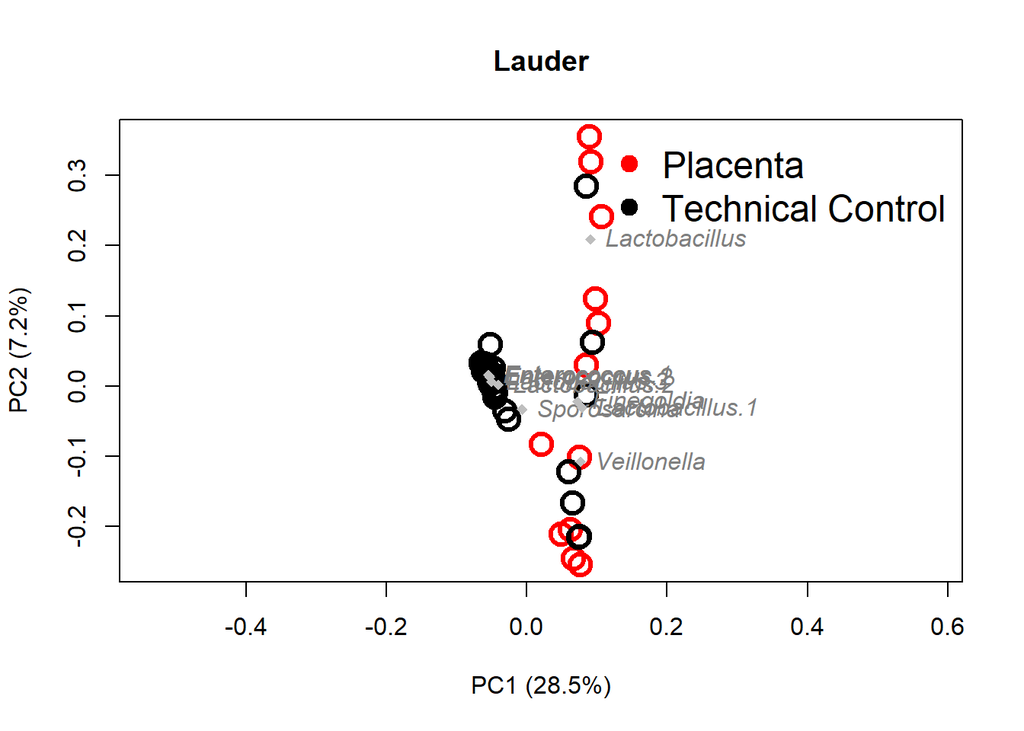

```r
#Figure 3A Placental Samples/Technical Controls
#allows plotting which extends past plot window
par(xpd= FALSE)
#sets palette
palette(c("red", "black"))
#plots PCoA of placental samples contrasted with technical controls
Lauder_Beta_plot_PTCWA <- beta_div(df = Lauder_ASV_PTC, df_meta = Lauder_META_PTC, type = "Type", study = "Lauder", all_O = TRUE, taxa_on_rows = TRUE, size = 2)
#returns top ten ranked ASVs by mean relative abundance in the dataset
Lauder_topASVs <- rowSums(Lauder_ASV_PTC) %>% sort(., decreasing = TRUE) %>% head(., 10)
#characterizes ordination space with ASV genus level classifications
WA_labels(Plot_object = Lauder_Beta_plot_PTCWA, ASV_table = Lauder_ASV_PTC, TAX_table = Lauder_TAX_PTC, ASVs_on_rows = TRUE, ASV_with_Genus = FALSE, Tax_col = "Genus", color = "grey", Greater_than_1per = FALSE, ASVs_to_plot = names(Lauder_topASVs))
```

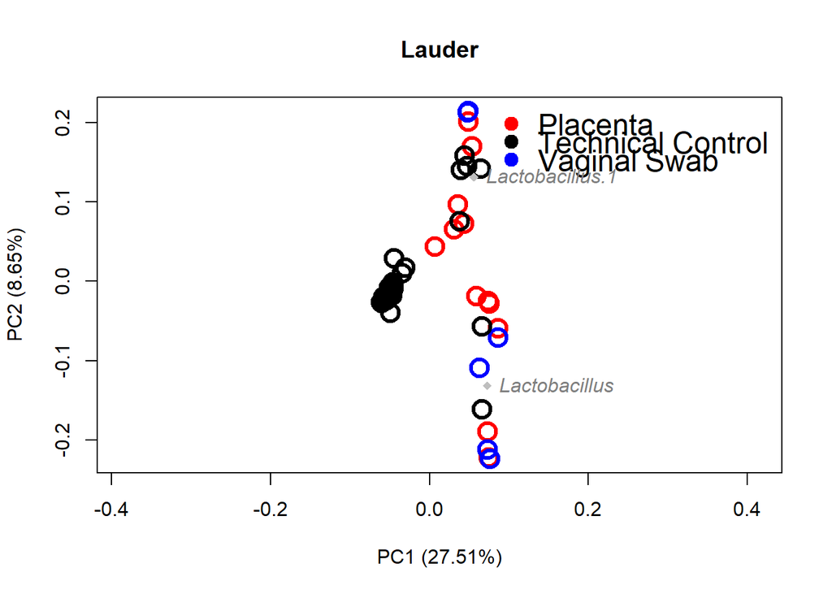

```r
#Figure 4A Placental Samples/Technical Controls/Vaginal Swabs
#allows plotting which extends past plot window
par(xpd= FALSE)
#sets palette
palette(c("red", "black", "blue"))
#plots PCoA of placental samples contrasted with technical controls and vaginal swabs
Lauder_Beta_plot_PTCVWA <- beta_div(df = Lauder_rare_ASV, df_meta = Lauder_rare_META, type = "Type", study = "Lauder", all_O = TRUE, taxa_on_rows = TRUE, size = 2, Legend_Yspace = .5)
#returns top ten ranked ASVs in placental samples and technical controls
Lauder_top10ASV_PTC <- rowSums(Lauder_ASV_PTC) %>% sort(., decreasing = TRUE) %>% head(., 10)
#returns top ten ranked ASVs in vaginal swab samples
Lauder_top10ASV_V <- rowSums(Lauder_rare_ASV %>% select_if(Lauder_rare_META$Type == "Vaginal Swab")) %>% sort(., decreasing = TRUE) %>% head(., 10)
#returns shared ASVs between the sample types
Lauder_top10shared <- Lauder_top10ASV_PTC[names(Lauder_top10ASV_PTC) %in% names(Lauder_top10ASV_V)]
#characterizes ordination space with ASV genus level classifications
WA_labels(Plot_object = Lauder_Beta_plot_PTCVWA, ASV_table = Lauder_rare_ASV, TAX_table = Lauder_rare_TAX, ASVs_on_rows = TRUE, ASV_with_Genus = FALSE, Tax_col = "Genus", color = "grey", Greater_than_1per = FALSE, ASVs_to_plot = names(Lauder_top10shared))
```

## Leiby et al. analysis

### Leiby et al. data cleaning

```r
#Loads both sequence and metadata
Leiby_merged <- read.csv("Leiby_merged.csv", stringsAsFactors = FALSE); Leiby_meta <- read.csv("Leiby_SraRunTable.csv", stringsAsFactors = FALSE)
#additional supplementary table from Leiby supplementary materials
Leiby_meta_supp <- read_xls("Leiby_Additional_file_1.xls", sheet = "Table S11")
#subsets supplementary metadata and renames columns
Leiby_meta_supp <- Leiby_meta_supp[,c("Group", "#SampleID", "Case/Control", "delivery")]; colnames(Leiby_meta_supp) <- c("Subject", "Sample.Name", "GA", "Delivery")

#TO BE REMOVED
#internal command to remove prefixes from columnnames and reorder columns. Others will not have to run this.
colnames(Leiby_merged)[9:ncol(Leiby_merged)] <- sub(pattern = "(\\D+)(.)(SRR\\S+)", replacement = "\\3", x = colnames(Leiby_merged)[9:ncol(Leiby_merged)])
Leiby_asv <- Leiby_merged[,9:ncol(Leiby_merged)]; Leiby_asv <- Leiby_asv[, order(colnames(Leiby_asv))]; Leiby_merged <- cbind(Leiby_merged[,1:8], Leiby_asv)

##cleans sequence data and renames rows with numbered ASVs
Leiby_merged_clean <- dadaset_clean(df = Leiby_merged, read_thresh = 100); rownames(Leiby_merged_clean) <- paste0("ASV", 1:nrow(Leiby_merged_clean))
```

```
## Originally there were 3680 taxa.
##  61 were not bacterial or classified at phylum level.
##  3 were mitochondrial. 8 were chloroplast.
##  3608 taxa remain. 54 samples eliminated with less than 100 reads: SRR7048677 SRR7048681 SRR7048682 SRR7048683 SRR7048684 SRR7048686 SRR7048718 SRR7048724 SRR7048763 SRR7048777 SRR7048778 SRR7048780 SRR7048781 SRR7048784 SRR7048788 SRR7048790 SRR7048803 SRR7048869 SRR7048870 SRR7048871 SRR7048887…
```

```r
#splits merged sequence data into an `ASV` count table and a taxonomy `TAX` object.
Leiby_ASV <- Leiby_merged_clean[,9:ncol(Leiby_merged_clean)]; Leiby_TAX <- Leiby_merged_clean[,1:8]

#subsets metadata to pertinent variables, filters samples to those in ASV count table
Leiby_META <- Leiby_meta %>% select_if(colnames(.) %in% c("Run", "Sample.Name", "Host")); Leiby_META <- Leiby_META %>% filter(Run %in% colnames(Leiby_ASV))
#merges supplementary metadata with metadata and gives sample names as rownames
Leiby_META <- merge(Leiby_META, Leiby_meta_supp, by.x = "Sample.Name", sort = FALSE); rownames(Leiby_META) <- Leiby_META$Sample.Name
#recodes subject metadata
for(i in 1:nrow(Leiby_META)){
    if(Leiby_META$Host[i] == ""){
        Leiby_META$Subject[i] <- NA
    }
}
#recodes `Type` metadata
Leiby_META$Type <- case_when(
    str_detect(string = Leiby_META$Sample.Name, pattern = "VS") ~ "Vaginal Swab",
    str_detect(string = Leiby_META$Sample.Name, pattern = "[FM]P\\d+") ~ "Placenta",
    str_detect(string = Leiby_META$Sample.Name, pattern = "[HAB]") ~ "Technical Control"
)
#adds combined Delivery/Gestation Age column
Leiby_META <- Leiby_META %>% mutate(Del_GA = paste(Delivery, GA, sep = " "))
#adds a column for Type/Delivery/Gestational Age
Leiby_META <- Leiby_META %>% mutate(Type_Del_GA = paste(Type, Delivery, GA, sep = " "))
Leiby_META<- Leiby_META %>% mutate(Type_Del_GA = case_when(
  str_detect(string = Leiby_META$Type, pattern = "^T") ~ "Technical Control",
  str_detect(string = Leiby_META$Type, pattern = "^V") ~ "Vaginal Swab",
  str_detect(string = Leiby_META$Type, pattern = "^P") ~ Type_Del_GA
))

#Reclassifies ASV433 which shares 99.05% identity to type strain Planococcus.
Leiby_TAX$Genus[match(x = "ASV433", table = rownames(Leiby_TAX))] <- "Planococcus*"
```

### Leiby et al. subset pre-DECONTAM

```r
#subsets metadata to placental samples and technical controls.
LeibyD_META_PTC <- Leiby_META %>% filter(Type == "Placenta" | Type == "Technical Control")
#subsets ASV count table to samples remaining in metadata and removes ASVs which no longer have reads remaining in the dataset
LeibyD_ASV_PTC <- Leiby_ASV %>% select_if(colnames(.) %in% LeibyD_META_PTC$Run); LeibyD_ASV_PTC <- LeibyD_ASV_PTC %>% filter(rowSums(.) > 0)
#filters taxonomy to match remaining ASVs in ASV count table
LeibyD_TAX_PTC <- Leiby_TAX %>% filter(rownames(.) %in% rownames(LeibyD_ASV_PTC))
```

### Leiby et al. DECONTAM

```r
#DECONTAM requires a column indicating which samples are to be considered samples and which are controls
LeibyD_META_PTC$Deco_type <- case_when(LeibyD_META_PTC$Type == "Placenta" ~ "sample", LeibyD_META_PTC$Type == "Technical Control" ~ "control")
#prepares data for DECONTAM
Leiby_DECO_prep <- decontam_prep(df = cbind(LeibyD_TAX_PTC, LeibyD_ASV_PTC), meta = LeibyD_META_PTC, type = "Deco_type", sample_col = "Run")
#generates histogram and prevalence plots comparing ASVs by prevalence in samples vs. controls
DECO_plots_Leiby <- decontam_histo_prev_plots(physeq = Leiby_DECO_prep, thresh = 0.17, study_name = "Leiby")
```

```
## [1] "True represents true taxa:"
##
## FALSE  TRUE
##  2884   278
```

```r
#removes likely contaminants with a threshold of 0.17
Leiby_decontaminated <- decontaminate(df = cbind(LeibyD_TAX_PTC, LeibyD_ASV_PTC), physeq = Leiby_DECO_prep, thresh = 0.17)
#returns taxa considered to be truly in the sample
Leiby_true_taxa <- Leiby_decontaminated$TrueTaxa
```

### Leiby et al. normalization

```r
#pre-DECONTAM dataset normalization
#visualization of sampling depth variance across dataset
table(colSums(Leiby_ASV))
```

```
##
##    107    108    115    119    120    121    122    127    131    132    134
##      1      1      1      1      1      1      1      1      1      1      1
##    135    136    148    159    162    165    166    169    171    189    194
##      1      3      1      1      1      1      1      1      1      2      1
##    200    203    205    215    219    226    230    253    260    264    269
##      1      1      1      1      1      1      1      2      1      1      1
##    274    300    302    311    316    317    321    326    383    386    402
##      1      1      1      1      2      1      1      1      1      1      1
##    409    430    433    443    445    447    454    462    510    534    543
##      1      1      1      1      1      1      1      1      1      1      1
##    546    556    578    581    626    627    631    679    681    682    688
##      1      1      1      1      1      2      1      1      1      1      2
##    693    728    747    754    774    782    815    837    857    881    888
##      1      1      1      1      1      1      1      1      1      1      1
```

[output cut: 22 more lines]

```r
#converts dataset to phyloseq object
phy <- phyloseqize(merged_df = Leiby_ASV, taxa_as_rows = TRUE, keep_ASV_nums = TRUE, tax_df = Leiby_TAX)
#normalizes samples to the greater of either the minimum number of sequences per sample in a dataset or 100. Samples with less than 100 sequences at this point are removed.
rarefied <- rarefy_even_depth(phy, sample.size = max(c(min(sample_sums(phy)), 100)), rngseed = 1, replace = FALSE)
```

```
## `set.seed(1)` was used to initialize repeatable random subsampling.
```

```
## Please record this for your records so others can reproduce.
```

```
## Try `set.seed(1); .Random.seed` for the full vector
```

```
## ...
```

```
## 1379OTUs were removed because they are no longer
## present in any sample after random subsampling
```

```
## ...
```

```r
#converts phyloseq object back to merged data frame
merged_rare <- dephy(rarefied)
#splits dataframe into `ASV` count table, `TAX` taxonomy, and ensures that metadata is current with remaining samples.
Leiby_rare_ASV <- merged_rare[,9:ncol(merged_rare)]; Leiby_rare_TAX <- merged_rare[,1:8]; Leiby_rare_META <- Leiby_META %>% filter(Run %in% colnames(Leiby_rare_ASV))

#post-DECONTAM Normalization
#visualization of sampling depth variance across dataset
table(colSums(Leiby_true_taxa[,9:ncol(Leiby_true_taxa)]))
```

```
##
##      0      1      2      3      5      6      7      8     10     16     17
##      9      4      2      1      2      1      1      1      1      1      1
##     18     19     20     23     26     27     29     30     31     35     37
##      1      3      2      2      1      1      2      1      1      1      2
##     38     41     42     43     44     45     46     47     48     50     51
##      1      1      1      2      2      1      3      1      2      1      1
##     54     59     63     66     69     70     71     73     74     77     78
##      1      1      1      1      2      1      1      1      1      1      1
##     79     80     82     84     86     87     89     92     94     95     97
##      1      1      2      1      1      2      1      1      1      1      2
##     98     99    104    107    108    109    111    118    126    131    133
##      1      1      1      1      1      1      1      1      1      1      1
##    135    153    188    193    194    198    200    209    219    227    233
##      1      1      1      2      1      1      1      1      1      1      1
##    236    241    244    269    270    272    275    304    330    340    350
##      1      1      1      1      1      1      1      1      2      1      1
##    351    352    354    361    378    386    403    420    448    453    503
##      1      1      1      1      1      1      1      1      1      1      1
##    541    573    581    641    657    714    721    739    802    895    916
##      1      1      1      1      1      1      1      1      1      1      1
##    928   1059   1061   1178   1371   1401   1449   1488   1533   1623   1638
##      1      1      1      1      1      1      1      1      1      1      1
##   1755   2436   2481   4516   4547   5767   6318   9603  25686  31061  42151
##      1      1      1      1      1      1      1      1      1      1      1
## 130955
##      1
```

```r
#converts dataset to phyloseq object
phy <- phyloseqize(cbind(Leiby_true_taxa[,1:8], Leiby_true_taxa[,9:ncol(Leiby_true_taxa)]))
#normalizes samples to the greater of either the minimum number of sequences per sample in a dataset or 100. Samples with less than 100 sequences at this point are removed.
rarefied <- rarefy_even_depth(physeq = phy, sample.size = max(min(sample_sums(phy)), 100), rngseed = 1, replace = FALSE)
```

```
## `set.seed(1)` was used to initialize repeatable random subsampling.
```

```
## Please record this for your records so others can reproduce.
```

```
## Try `set.seed(1); .Random.seed` for the full vector
```

```
## ...
```

```
## 85 samples removedbecause they contained fewer reads than `sample.size`.
```

```
## Up to first five removed samples are:
```

```
## SRR7048664SRR7048676SRR7048687SRR7048688SRR7048691
```

```
## ...
```

```
## 29OTUs were removed because they are no longer
## present in any sample after random subsampling
```

```
## ...
```

```r
#converts phyloseq object back to merged data frame
merged_rare <- dephy(rarefied)
```

### Leiby et al. post-Normalization subsets

```r
#post-DECONTAM dataset after normalization does not need technical controls
LeibyD_rare_META <- Leiby_META %>% filter(Run %in% colnames(merged_rare[,9:ncol(merged_rare)]) & Type == "Placenta")
#splits dataframe into `ASV` count table, `TAX` taxonomy
LeibyD_rare_ASV <- merged_rare[,9:ncol(merged_rare)]; LeibyD_rare_TAX <- merged_rare[,1:8]
#removes technical controls from `ASV` count table and removes ASVs no longer present in samples
LeibyD_rare_ASV <- LeibyD_rare_ASV %>% select_if(colnames(.) %in% LeibyD_rare_META$Run); LeibyD_rare_ASV <- LeibyD_rare_ASV %>% filter(rowSums(.) > 0)
#keeps taxonomy current with count table.
LeibyD_rare_TAX <- LeibyD_rare_TAX %>% filter(rownames(.) %in% rownames(LeibyD_rare_ASV))
#stores top five ranked ASVs by mean relative abundance in post-DECONTAM dataset
Top5_Leiby_DECO <- top_ASVs_above_cutoff(ASV = LeibyD_rare_ASV, TAX = LeibyD_rare_TAX, cutoff = 0.01, top = 5, ASVs_on_Rows = TRUE, study = "Leiby")

#pre-DECONTAM post-normalization subsets
#selects placental samples and technical controls and removes samples no longer in the metadata
Leiby_META_PTC <- Leiby_rare_META %>% filter(Type == "Placenta" | Type == "Technical Control")
#updates ASV count table and removes ASVs no longer in the dataset
Leiby_ASV_PTC <- Leiby_rare_ASV %>% select_if(colnames(.) %in% Leiby_META_PTC$Run); Leiby_ASV_PTC <- Leiby_ASV_PTC %>% filter(rowSums(.) > 0)
#updates taxonomy to match ASV count table
Leiby_TAX_PTC <- Leiby_rare_TAX %>% filter(rownames(.) %in% rownames(Leiby_ASV_PTC))


#Only Placental Subset
Leiby_ASV_P <- Leiby_rare_ASV %>% select_if(Leiby_rare_META$Host != "" & !str_detect(string = Leiby_rare_META$Sample.Name, pattern = "VS")); Leiby_ASV_P <- Leiby_ASV_P %>% filter(rowSums(.) > 0)
#updates metadata and taxonomy to match ASV count table
Leiby_META_P <- Leiby_rare_META %>% filter(Run %in% colnames(Leiby_ASV_P)); Leiby_TAX_P <- Leiby_rare_TAX %>% filter(rownames(.) %in% rownames(Leiby_ASV_P))
#stores top five ranked ASVs by mean relative abundance in pre-DECONTAM dataset
Top5_Leiby <- top_ASVs_above_cutoff(ASV = Leiby_ASV_P, TAX = Leiby_TAX_P, cutoff = 0.01, top = 5, ASVs_on_Rows = TRUE, study = "Leiby")
```

### Leiby et al. PCoAs

Code for Figures 3B and 4B

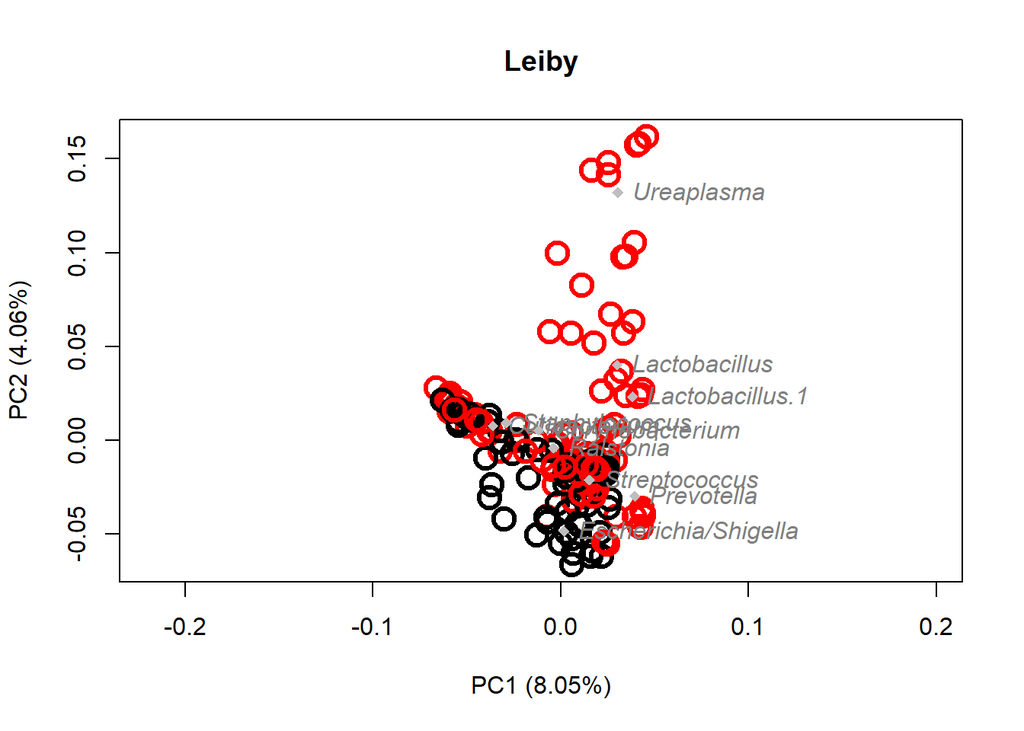

```r
#Figure 3B Placental Samples/Technical Controls
#allows plotting which extends past plot window
par(xpd = FALSE)
#sets palette
palette(c("red", "black"))
#plots PCoA of placental samples contrasted with technical controls and vaginal swabs
Leiby_Beta_plot_PTCWA <- beta_div(df = Leiby_ASV_PTC, df_meta = Leiby_META_PTC, type = "Type", study = "Leiby", inset = 0, all_O = TRUE, taxa_on_rows = TRUE, size = 2, legendyn = FALSE)
#returns top ten ranked ASVs by mean relative abundance in the dataset
Leiby_topASVs <- rowSums(Leiby_ASV_PTC) %>% sort(., decreasing = TRUE) %>% head(., 10)
#characterizes ordination space with ASV genus level classifications
WA_labels(Plot_object = Leiby_Beta_plot_PTCWA, ASV_table = Leiby_ASV_PTC, TAX_table = Leiby_TAX_PTC, ASVs_on_rows = TRUE, ASV_with_Genus = FALSE, Tax_col = "Genus", color = "grey", Greater_than_1per = FALSE, ASVs_to_plot = names(Leiby_topASVs))
```

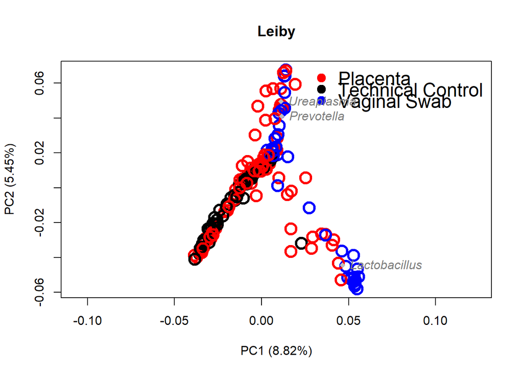

```r
#Fig 4B Leiby Placental Samples/Technical Controls/Vaginal Swabs
#allows plotting which extends past plot window
par(xpd = FALSE)
#sets palette
palette(c("red", "black", "blue"))
#plots PCoA of placental samples contrasted with technical controls and vaginal swabs
Leiby_Beta_plot_PTCVWA <- beta_div(Leiby_rare_ASV, df_meta = Leiby_rare_META, type = "Type", study = "Leiby", all_O = TRUE, taxa_on_rows = TRUE, size = 2, Legend_Yspace = .5)
#returns top ten ranked ASVs in placental samples and technical controls
Leiby_top10ASV_PTC <- rowSums(Leiby_rare_ASV %>% select_if(Leiby_rare_META$Type == "Technical Control" | Leiby_rare_META$Type == "Placenta")) %>% sort(., decreasing = TRUE) %>% head(., 10)
#returns top ten ranked ASVs in vaginal swab samples
Leiby_top10ASV_V <- rowSums(Leiby_rare_ASV %>% select_if(Leiby_rare_META$Type == "Vaginal Swab")) %>% sort(., decreasing = TRUE) %>% head(., 10)
#returns shared ASVs between the sample types
Leiby_top10_shared <- Leiby_top10ASV_PTC[names(Leiby_top10ASV_PTC) %in% names(Leiby_top10ASV_V)]
#characterizes ordination space with ASV genus level classifications
WA_labels(Plot_object = Leiby_Beta_plot_PTCVWA, ASV_table = Leiby_rare_ASV, TAX_table = Leiby_rare_TAX, ASVs_on_rows = TRUE, ASV_with_Genus = FALSE, Tax_col = "Genus", color = "grey", Greater_than_1per = FALSE, ASVs_to_plot = names(Leiby_top10_shared))
```

## Leon et al. analysis

### Leon et al. data cleaning

```r
#Loads sequence data
Leon_merged <- read.csv(file = "Leon_merged.csv", stringsAsFactors = FALSE)
#metadata taken from sample column names in merged data
Leon_meta <- data.frame(Sample = colnames(Leon_merged[,9:ncol(Leon_merged)]))
#adds Run data from `Sample` column
Leon_meta$Run <- gsub(pattern = "\\b(Run[1234])(_)(\\S*)", replacement = "\\1", x = Leon_meta$Sample)
#replaces sample column with only sample names
Leon_meta$Sample <- gsub(pattern = "\\b(Run[1234])(_)(\\S*)", replacement = "\\3", x = Leon_meta$Sample)
#filters metadata to samples from runs 1 and 4, which had the highest quality
Leon_meta <- Leon_meta %>% filter(Run %in% c("Run1", "Run4"))
#replaces lowercase `p` with uppercase `P`
Leon_meta$Sample[match("p339", table = Leon_meta$Sample)] <- "P339"

#determines which samples are from run 4 and run 1
Run4_samples <- Leon_meta %>% filter(Run == "Run4") %>% pull(Sample); Run1_samples <- Leon_meta %>% filter(Run == "Run1") %>% pull(Sample)
#determines the indices of shared samples which are in both runs, and removes run 4 samples from metadata which were also processed in run 1
Shared_Samples <- Run4_samples[Run4_samples %in% Run1_samples]; shared_indices <- which(Leon_meta$Sample %in% Shared_Samples); shared_indices <- shared_indices[shared_indices > 256]; Leon_meta <- Leon_meta[-c(shared_indices),]
#removes mock samples from metadata
Leon_meta <- Leon_meta[!grepl(pattern = "\\bM", x = Leon_meta$Sample),]
#recodes type column
Leon_meta$Type <- case_when(
str_detect(Leon_meta$Sample,"\\bN") ~ "Technical Control",
str_detect(Leon_meta$Sample, "\\bW") ~ "Technical Control",
str_detect(Leon_meta$Sample, "\\b[PV]") ~ "Placenta")

#filters merged data to samples in metadata
Leon_merged <- cbind(Leon_merged[,1:8], Leon_merged[,9:ncol(Leon_merged)] %>% select_if(toupper(colnames(.)) %in% toupper(paste(Leon_meta$Run, Leon_meta$Sample, sep = "_"))))

#cleans sequence data and renames rows with numbered ASVs
Leon_merged_clean <- dadaset_clean(df = Leon_merged, read_thresh = 100); rownames(Leon_merged_clean) <- paste0("ASV", 1:nrow(Leon_merged_clean))
```

```
## Originally there were 5200 taxa.
##  62 were not bacterial or classified at phylum level.
##  0 were mitochondrial. 27 were chloroplast.
##  5111 taxa remain. 16 samples eliminated with less than 100 reads: Run1_N15 Run1_P109.2 Run1_P180 Run1_P377 Run1_P406 Run1_P658 Run1_P79 Run1_V1125 Run1_V1841 Run4_P109 Run4_P15 Run4_P397 Run4_P47 Run4_P518 Run4_P600 Run4_P668
```

```r
#renames column names in merged dataset
colnames(Leon_merged_clean)[9:ncol(Leon_merged_clean)] <- toupper(gsub(pattern = "\\b(Run[1234])(_)(\\S*)", replacement = "\\3", x = colnames(Leon_merged_clean)[9:ncol(Leon_merged_clean)]))
#splits merged sequence data into an `ASV` count table and a taxonomy `TAX` object.
Leon_ASV <- Leon_merged_clean[,9:ncol(Leon_merged_clean)]; Leon_TAX <- Leon_merged_clean[,1:8]

#filters metadata to those in ASV count table
Leon_META <- Leon_meta %>% filter((Sample) %in% colnames(Leon_merged_clean))
```

### Leon et al. DECONTAM

```r
#DECONTAM requires a column indicating which samples are to be considered samples and which are controls
Leon_META$Deco_type <- case_when(
  Leon_META$Type == "Placenta" ~ "sample",
  Leon_META$Type == "Technical Control" ~ "control")
#prepares data for DECONTAM
Leon_DECO_prep <- decontam_prep(df = Leon_merged_clean, meta = Leon_META, type = "Deco_type", sample_col = "Sample")
#generates histogram and prevalence plots comparing ASVs by prevalence in samples vs. controls
DECO_plots_Leon <- decontam_histo_prev_plots(physeq = Leon_DECO_prep, thresh = 0.19, study_name = "Leon")
```

```
## [1] "True represents true taxa:"
##
## FALSE  TRUE
##  5033    78
```

```r
#removes likely contaminants with a threshold of 0.19
Leon_decontaminated <- decontaminate(df = Leon_merged_clean, physeq = Leon_DECO_prep, thresh = 0.19)
#returns taxa considered to be truly in the sample
Leon_true_taxa <- Leon_decontaminated$TrueTaxa
```

### Leon et al. normalization

```r
#pre-DECONTAM dataset normalization
#visualization of sampling depth variance across dataset
table(colSums(Leon_ASV))
```

```
##
##   106   121   122   124   134   138   145   147   148   153   157   170   178
##     1     1     1     1     1     2     1     1     1     1     1     1     1
##   179   195   197   198   212   213   214   215   219   220   234   236   241
##     1     1     1     1     1     1     1     1     1     2     1     1     1
##   244   252   256   257   259   260   261   262   275   280   287   288   289
##     1     2     1     1     1     1     1     1     1     1     1     1     1
##   294   296   297   298   308   311   313   315   329   335   339   346   349
##     1     2     1     1     1     2     1     1     1     1     1     1     1
##   350   363   365   367   381   382   387   390   392   400   411   416   423
##     1     1     1     1     1     1     1     1     1     1     2     1     1
##   426   438   442   444   455   456   458   467   476   477   484   490   494
##     1     1     1     1     1     1     1     1     1     1     1     2     1
##   497   502   506   510   516   530   537   541   547   553   579   584   588
##     1     1     1     1     1     1     1     1     2     1     1     1     1
```

[output cut: 48 more lines]

```r
#converts dataset to phyloseq object
phy <- phyloseqize(merged_df = Leon_ASV, taxa_as_rows = TRUE, keep_ASV_nums = TRUE, tax_df = Leon_TAX)
#normalizes samples to the greater of either the minimum number of sequences per sample in a dataset or 100. Samples with less than 100 sequences at this point are removed.
rarefied <- rarefy_even_depth(phy, rngseed = 1, replace = FALSE)
```

```
## `set.seed(1)` was used to initialize repeatable random subsampling.
```

```
## Please record this for your records so others can reproduce.
```

```
## Try `set.seed(1); .Random.seed` for the full vector
```

```
## ...
```

```
## 2412OTUs were removed because they are no longer
## present in any sample after random subsampling
```

```
## ...
```

```r
#converts phyloseq object back to merged data frame
merged_rare <- dephy(rarefied)
#splits dataframe into `ASV` count table, `TAX` taxonomy, and ensures that metadata is current with remaining samples.
Leon_rare_ASV <- merged_rare[,9:ncol(merged_rare)]; Leon_rare_TAX <- merged_rare[,1:8]; Leon_rare_META <- Leon_META %>% filter(Sample %in% colnames(Leon_rare_ASV))

#post-DECONTAM Normalization
#visualization of sampling depth variance across dataset
table(colSums(Leon_true_taxa[,9:ncol(Leon_true_taxa)]))
```

```
##
##     0     1     2     3     4     5     8     9    10    11    12    13    14
##    22     7     5     1     3     1     1     3     2     2     2     4     2
##    16    17    18    20    22    23    24    25    26    27    28    29    30
##     1     5     3     3     2     2     1     3     2     2     3     1     2
##    31    32    33    34    35    36    37    38    40    41    42    43    44
##     2     1     1     6     1     1     3     1     3     6     1     3     3
##    45    46    48    49    50    52    53    55    56    57    58    59    64
##     6     1     1     2     2     1     2     2     1     2     1     1     1
##    66    67    68    70    72    73    75    76    77    78    79    81    82
##     1     1     1     2     1     1     2     1     2     2     1     1     2
##    84    85    87    92    93    95    96    97    98   100   101   102   103
##     2     4     1     1     2     2     2     1     1     1     2     1     1
##   104   105   106   109   110   111   112   113   114   117   118   120   121
##     2     1     1     2     1     1     1     1     1     2     1     1     1
```

[output cut: 32 more lines]

```r
#converts dataset to phyloseq object
phy <- phyloseqize(Leon_true_taxa)
#normalizes samples to the greater of either the minimum number of sequences per sample in a dataset or 100. Samples with less than 100 sequences at this point are removed.
rarefied <- rarefy_even_depth(physeq = phy, sample.size = max(min(sample_sums(phy)), 100), rngseed = 1, replace = FALSE)
```

```
## `set.seed(1)` was used to initialize repeatable random subsampling.
```

```
## Please record this for your records so others can reproduce.
```

```
## Try `set.seed(1); .Random.seed` for the full vector
```

```
## ...
```

```
## 174 samples removedbecause they contained fewer reads than `sample.size`.
```

```
## Up to first five removed samples are:
```

```
## N16N2N26N9P103
```

```
## ...
```

```r
#converts phyloseq object back to merged data frame
merged_rare <- dephy(rarefied)
```

### Leon et al. post-normalization subsets

```r
#post-DECONTAM dataset after normalization does not need technical controls
LeonD_rare_META <- Leon_META %>% filter(Sample %in% colnames(merged_rare[,9:ncol(merged_rare)]) & Type == "Placenta")
#splits dataframe into `ASV` count table, `TAX` taxonomy
LeonD_rare_ASV <- merged_rare[,9:ncol(merged_rare)]; LeonD_rare_TAX <- merged_rare[,1:8]
#removes technical controls from `ASV` count table and removes ASVs no longer present in samples
LeonD_rare_ASV <- LeonD_rare_ASV %>% select_if(colnames(.) %in% LeonD_rare_META$Sample); LeonD_rare_ASV <- LeonD_rare_ASV %>% filter(rowSums(.) > 0)
#keeps taxonomy current with count table.
LeonD_rare_TAX <- LeonD_rare_TAX %>% filter(rownames(.) %in% rownames(LeonD_rare_ASV))
#stores top five ranked ASVs by mean relative abundance in post-DECONTAM dataset
Top5_Leon_DECO <- top_ASVs_above_cutoff(ASV = LeonD_rare_ASV, TAX = LeonD_rare_TAX, cutoff = 0.01, top = 5, ASVs_on_Rows = TRUE, study = "Leon")

#Only Placental Subset
Leon_ASV_P <- Leon_rare_ASV %>% select_if(Leon_rare_META$Type == "Placenta"); Leon_ASV_P <- Leon_ASV_P %>% filter(rowSums(.) > 0)
#updates metadata and taxonomy to match ASV count table
Leon_META_P <- Leon_rare_META %>% filter(Type == "Placenta"); Leon_TAX_P <- Leon_rare_TAX %>% filter(rownames(.) %in% rownames(Leon_ASV_P))
#stores top five ranked ASVs by mean relative abundance in pre-DECONTAM dataset
Top5_Leon <- top_ASVs_above_cutoff(ASV = Leon_ASV_P, TAX = Leon_TAX_P, cutoff = 0.01, top = 5, ASVs_on_Rows = TRUE, study = "Leon")
```

### Leon et al. PCoA

Code for Figure 3C

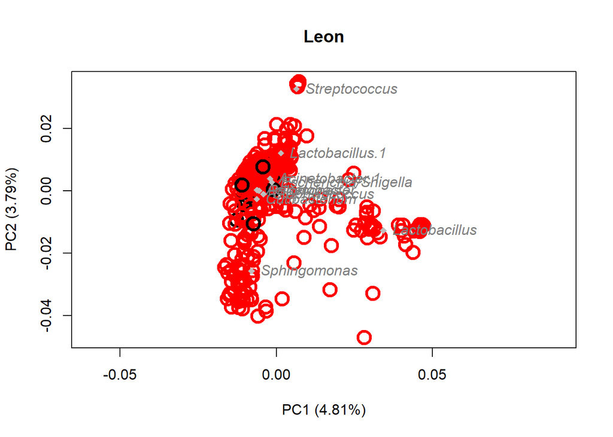

```r
#Figure 3C
#allows plotting which extends past plot window
par(xpd = FALSE)
#sets palette
palette(c("red", "black"))
#plots PCoA of placental samples contrasted with technical controls and vaginal swabs
Leon_Beta_plot_PTCWA <- beta_div(df = Leon_rare_ASV, df_meta = Leon_rare_META, type = "Type", study = "Leon", all_O = TRUE, taxa_on_rows = TRUE, legendyn = FALSE, size = 2)
#returns top ten ranked ASVs by mean relative abundance in the dataset
Leon_topASVs <- rowSums(Leon_rare_ASV) %>% sort(., decreasing = TRUE) %>% head(., 10)
#characterizes ordination space with ASV genus level classifications
WA_labels(Plot_object = Leon_Beta_plot_PTCWA, ASV_table = Leon_rare_ASV, TAX_table = Leon_rare_TAX, ASVs_on_rows = TRUE, ASV_with_Genus = FALSE, Tax_col = "Genus", color = "grey", Greater_than_1per = FALSE, ASVs_to_plot = names(Leon_topASVs))
```

## Liu et al. analysis

### Liu et al. data cleaning

```r
#Loads both sequence and metadata and supplementary metadata
Liu_merged <- read.csv(file = "Liu_merged.csv", stringsAsFactors = FALSE); Liu_meta <- read.csv(file = "Liu_SraRunTable.csv", stringsAsFactors = FALSE); Liu_meta_supp <- read.xlsx("Liu_Metadata2.xlsx")
#renames columns with first row of supplementary metadata and trims rows to actual samples
colnames(Liu_meta_supp) <- Liu_meta_supp[1,];colnames(Liu_meta_supp)[c(1,7)] <- c("Sample", "Delivery"); Liu_meta_supp <- Liu_meta_supp[3:80,]; rownames(Liu_meta_supp) <- 1:78; Liu_meta_supp$Sample <- paste0(Liu_meta_supp$Sample, "p"); Liu_meta_supp <- Liu_meta_supp[,c(1:8,11)]
#selects columns from metadata and renames them
Liu_meta <- Liu_meta %>% select_if(colnames(.) %in% c("Run", "Library.Name")); colnames(Liu_meta)[2] <- "Sample"
#filters metadata to only placental samples and removes trailing `p`
Liu_meta <- Liu_meta[grepl(pattern = "(\\D)(\\d+)([py])", x = Liu_meta$Sample),];Liu_meta$Type <- case_when(
  str_detect(string = Liu_meta$Sample, pattern = "p$") ~ "Placenta",
  str_detect(string = Liu_meta$Sample, pattern = "y$") ~ "Vaginal Swab"
)
#merges metadata and supplemental metadata and orders the data by run
Liu_meta <- merge(Liu_meta, Liu_meta_supp, by = "Sample", all.x = TRUE); Liu_meta <- Liu_meta[order(Liu_meta$Run),]
#removes trailing `p` and `y`
Liu_meta$Sample <- sub(pattern = "(\\D)(\\d+)([py])", replacement = "\\1\\2", x = Liu_meta$Sample)

#filters merged data to samples in metadata
Liu_merged <- cbind(Liu_merged[,1:8], Liu_merged %>% select_if(colnames(.) %in% Liu_meta$Run))
#cleans sequence data, renames rows with numbered ASVs, and adds empty species column to taxonomy
Liu_merged_clean <- dadaset_clean(Liu_merged, read_thresh = 100); rownames(Liu_merged_clean) <- paste0("ASV", 1:nrow(Liu_merged_clean));
```

```
## Originally there were 20375 taxa.
##  9536 were not bacterial or classified at phylum level.
##  3 were mitochondrial. 6 were chloroplast.
##  10830 taxa remain. 0 samples eliminated with less than 100 reads:
```

```r
#splits merged sequence data into an `ASV` count table and a taxonomy `TAX` object.
Liu_ASV <- Liu_merged_clean[,8:ncol(Liu_merged_clean)]; Liu_TAX <- Liu_merged_clean[,1:7]

#filters metadata to samples in ASV count table
Liu_META <- Liu_meta %>% filter(Run %in% colnames(Liu_ASV))

#Reclassifies ASV2 Enterobacterales which shares 99.74% identity with Pantoea agglomerans strain ATCC 27155
Liu_TAX$Genus[match("ASV2", rownames(Liu_TAX))] <- "Pantoea*"
#Reclassifies ASV22 Enterobacterales which shares 99.49% identity with Pantoea agglomerans strain ATCC 27155
Liu_TAX$Genus[match("ASV22", rownames(Liu_TAX))] <- "Pantoea*"
#Reclassifies ASV178 Enterobacterales which shares 99.74% identity with Pantoea agglomerans strain ATCC 27155
Liu_TAX$Genus[match("ASV178", rownames(Liu_TAX))] <- "Pantoea*"
```

### Liu et al. normalization

```r
#visualization of sampling depth variance across dataset
table(colSums(Liu_ASV))
```

```
##
##   552   640  1003  1091  1238  1263  1518  1601  1747  1899  1978  2155  2416
##     1     1     1     1     1     1     1     1     1     1     1     1     1
##  2629  2673  2685  3169  3506  3992  4005  4203  4225  4293  4367  4442  4467
##     1     1     1     1     1     1     1     1     1     1     1     1     1
##  4549  4633  4686  4735  4850  4891  4996  5010  5142  5347  5399  5436  5445
##     1     1     1     1     1     1     1     1     1     1     1     1     1
##  5576  5685  5999  6476  6505  6606  6708  6729  7138  7260  7442  7547  7594
##     1     1     1     1     1     1     1     1     1     1     1     1     1
##  7715  7874  8071  8088  8199  8458  8562  8719  8751  8839  8935  8954  8975
##     1     1     1     1     1     1     1     1     1     1     1     1     1
##  9063  9132  9236  9466  9493  9617  9652  9839  9976 10010 10050 10139 10149
##     1     1     1     1     1     1     1     1     1     1     1     1     1
## 10286 10391 10455 10676 10953 10961 10989 11085 11404 11753 11830 12017 12226
##     1     1     1     1     1     1     1     1     1     1     1     1     1
## 12337 12468 12530 12601 12612 12735 12818 12957 13013 13356 13450 13468 13613
##     1     1     1     1     1     1     1     1     1     1     1     1     1
## 13653 13971 14037 14266 14364 14560 15067 15141 15974 17327 17556 19233 19377
##     1     1     1     1     1     1     1     1     1     1     1     1     1
## 20747 20992 22128 27046
##     1     1     1     1
```

```r
#converts dataset to phyloseq object
phy <- phyloseqize(merged_df = Liu_ASV, taxa_as_rows = TRUE, keep_ASV_nums = TRUE, tax_df = Liu_TAX)
#normalizes samples to the greater of either the minimum number of sequences per sample in a dataset or 100. Samples with less than 100 sequences at this point are removed.
rarefied <- rarefy_even_depth(physeq = phy, sample.size = max(min(sample_sums(phy)), 100), rngseed = 1, replace = FALSE)
```

```
## `set.seed(1)` was used to initialize repeatable random subsampling.
```

```
## Please record this for your records so others can reproduce.
```

```
## Try `set.seed(1); .Random.seed` for the full vector
```

```
## ...
```

```
## 9092OTUs were removed because they are no longer
## present in any sample after random subsampling
```

```
## ...
```

```r
#converts phyloseq object back to merged data frame
merged_rare <- dephy(rarefied); merged_rare[,1:7] <- lapply(merged_rare[,1:7], as.character)
#splits dataframe into `ASV` count table, `TAX` taxonomy, and ensures that metadata is current with remaining samples.
Liu_rare_ASV <- merged_rare[,8:ncol(merged_rare)]; Liu_rare_TAX <- merged_rare[,1:7]; Liu_rare_META <- Liu_META %>% filter(Run %in% colnames(Liu_rare_ASV))
```

### Liu et al. post-normalization subsets

```r
#Liu Placental samples subset
Liu_META_P <- Liu_rare_META %>% filter(Type == "Placenta")
#selects placental samples in ASV count table and removes ASVs no longer present in samples
Liu_ASV_P <- Liu_rare_ASV %>% select_if(colnames(.) %in% Liu_META_P$Run); Liu_ASV_P <- Liu_ASV_P %>% filter(rowSums(.) > 0)
#keeps taxonomy current with count table.
Liu_TAX_P <- Liu_rare_TAX %>% filter(rownames(.) %in% rownames(Liu_ASV_P))

#strictly Cesarean delivered placental samples subset
#selects cesarean delivered samples in ASV count table and removes ASVs no longer present in samples
Liu_ASV_CS <- Liu_ASV_P %>% select_if(Liu_META_P$Delivery == "Cesarean delivered"); Liu_ASV_CS <- Liu_ASV_CS %>% filter(rowSums(.) > 0)
#filters out vaginally delivered placental samples
Liu_META_CS <- Liu_META_P %>% filter(Delivery == "Cesarean delivered")
#keeps taxonomy current with count table.
Liu_TAX_CS <- Liu_TAX_P %>% filter(rownames(.) %in% rownames(Liu_ASV_CS))
#needs species column
Liu_TAX_CS$Species <- as.character(NA)
#stores top five ranked ASVs by mean relative abundance in cesarean delivered placental samples
Top5_Liu <- top_ASVs_above_cutoff(ASV = Liu_ASV_CS, TAX = Liu_TAX_CS, cutoff = 0.01, top = 5, ASVs_on_Rows = TRUE, study = "Liu")
```